# Retinalogik vs HFA study scotoma analysis

[Eadie Technologies, Inc.](https://www.eadietech.com/)

2025-06-04

## Setup

### Versioning

Last updated on 2026-Apr-21 at 01:37 PM.

- 2025-Jun-04: Created separate .Rmd file as index.Rmd was getting very cluttered.
- 2025-Jul-16: Scripted using latest dataset with 1st 2 visits removed using reliable data & 1 eye only.
- 2025-Aug-01: Added t-tests and bargraph for Mild, Moderate, Advanced groups with Bonferroni correction.
- 2025-Oct-27: Added full dataset.
- 2026-Mar-03: Added Wilcoxon signed rank test for median values.

### Acknowledgements

Data collected by Research Assistants Luc St-Pierre, Reann Post, and Research Coordinator Lynn Murphy.

```r
# load packages
library(tidyverse)
```

```r
library(here)
## here() starts at /Users/eadie/EadieTech/retinalogik-study
library(DT)
library(plotly)
library(viridis)
library(svglite)
library(htmltools)
library(gridExtra)
library(sf)
## Linking to GEOS 3.13.0, GDAL 3.8.5, PROJ 9.5.1; sf_use_s2() is TRUE
library(spdep)
library(RColorBrewer)
library(patchwork)
library(spatstat.geom)
library(data.table)
library(ggplot2)
```

```r
# default chunk options
knitr::opts_chunk$set(
  comment = '>', collapse = TRUE, cache = FALSE, dev= c("png")
  )
```

# Study summary

We compared 24-2 visual field (VF) test results between Retinalogik and the Humphrey Field Analyzer (HFA) using SITA Standard test strategy in patients with early glaucoma and moderate to advanced glaucoma [here](https://vvnejl.github.io/retinalogik-study/). A scotoma analysis was performed following glaucomatous VF definitions found in Park et al. (2011).

# Methods (very briefly)

We define a scotoma as the presence of at least 3 vertically, horizontally, or diagonally contiguous test points within the same hemifield on the pattern deviation probability plot at p <5%, with at least 1 point at p <1%, excluding points directly above or below the blind spot. Only eyes with consistent glaucomatous VF loss on at least 2 consecutive examinations with reliability indices better than 30% were included.

## Analysis

```r
rm(list = ls())

load(here("dBdat.Rda"))
load(here("retinalogik_hfadatawpsd.Rda"))

dBdat_flipped <- dBdat %>%
  mutate(x = as.numeric(x), y = as.numeric(y)) %>%
  mutate(x = case_when(
    eye == "L" & device == "retinalogik" ~ x*-1,
    TRUE ~ as.numeric(x)
  )) %>%
  # remove blind spots
  filter(!(x == 15 & y == -3)) %>%
  filter(!(x == 15 & y == +3)) %>%
  #remove first 2 visits
  filter(visit != 1 & visit != 2) %>%
  #remove reliability indices >30%
  filter(flPerc < 30 & fnPerc < 30 & fpPerc < 30) %>%
  group_by(id, device, eye) %>%
  mutate(meanmd = mean(md))

classification <- readxl::read_excel("RetinaLogik Data Classification.xlsx") %>%
  mutate(
    # Extract the numeric part after "RL"
    numeric_part = as.numeric(str_extract(ID, "\\d+")),
    # Format the numeric part to have at least two digits with leading zeros
    formatted_numeric = str_pad(numeric_part, width = 2, side = "left", pad = "0"),
    # Combine "RL" with the formatted number
    ID = paste0("RL", formatted_numeric)
  ) %>%
  # Remove the temporary columns
  select(-numeric_part, -formatted_numeric) %>%
  rename(id = ID, classification = Classifcation, eye = `Eye (OD/OS)`) %>%
  mutate(eye = case_when(eye == "OS" ~ "L",
                         eye == "OD" ~ "R",
                         eye == "OU" ~ "R"))

dBdat_filtered <- merge(dBdat_flipped, classification)

psdpvalues_hfa <- alldat

tmp <- merge(psdpvalues_hfa, dBdat_filtered)

psddf <- psdpvalues_hfa %>%
  #remove first 2 visits
  filter(visit != 1 & visit != 2) %>%
  #remove reliability indices <30%
  filter(fl/flTest < 0.3 & fnPerc < 0.3 & fpPerc < 0.3) %>%
  #Group by patient ID and visual field coordinates
  group_by(id, eye, x, y) %>%
  # Filter to keep only groups with at least 2 unique visits
  #  filter(n_distinct(visit) >= 2) %>%
  # Filter for 2 consecutive visits
  filter(any(diff(sort(unique(visit))) == 1)) %>%
  # Filter to keep only groups with at least 2 unique visits
  filter(!is.na(psd_p)) %>%
  # Ungroup the data
  ungroup()

#write.csv(psddf,"~/Downloads/scotoma_hfa.csv", row.names = FALSE)
#write.csv(dBdat_filtered,"~/Downloads/alldata.csv", row.names = FALSE)

# Install and load necessary packages if you don't have them
# library(data.table)
# library(ggplot2)
# library(RColorBrewer)

# --- 1. Load the data ---
scotoma_hfa <- psddf
alldata <- dBdat_filtered

# --- 2. Define Blind Spots and Exclusion Points ---
excluded_points <- data.table(
  x = c(15, 15, 15, 15),
  y = c(3, -3, 9, -9)
)

# --- 3. Identify Scotoma in scotoma_hfa.csv ---

# Pre-filter for relevant conditions: psd_p < 5
scotoma_candidates <- scotoma_hfa %>%
  filter(psd_p < 5) %>%
  # Exclude blind spot and adjacent points
  anti_join(excluded_points, by = c("x", "y")) %>%
  arrange(id, eye, x, y) # Order for easier contiguity check

# Function to determine hemifield
get_hemifield <- function(y) {
  if (!is.numeric(y)) {
    warning("Input 'y' must be numeric.")
    return(NA)
  }

  return(ifelse(y >= 0, "Upper", "Lower"))
}

scotoma_candidates <- scotoma_candidates %>%
  rowwise() %>%
  mutate(hemifield = get_hemifield(y)) %>%
  ungroup()

# Initialize scotoma_id column
scotoma_candidates$scotoma_group <- NA_character_

# Define neighbor offsets for a 6-degree grid (standard HFA)
# These represent horizontal, vertical, and diagonal neighbors
neighbor_offsets <- expand.grid(dx = c(-6, 0, 6), dy = c(-6, 0, 6)) %>%
  filter(!(dx == 0 & dy == 0)) # Exclude (0,0) itself

# Function to find contiguous points and apply scotoma criteria
find_scotoma_clusters <- function(data) {
  data_dt <- as.data.table(data)
  data_dt[, `:=`(cluster_id = NA_integer_, visited = FALSE)]

  current_cluster_id <- 0

  # Group by id, eye, visit, and hemifield to process independently
  setkey(data_dt, id, eye, visit, hemifield) # Optimize grouping/subsetting

  for (i in 1:nrow(data_dt)) {
    if (data_dt$visited[i]) {
      next # Skip if already part of a processed cluster
    }

    # Start a new potential cluster (BFS/DFS)
    current_cluster_id <- current_cluster_id + 1
    queue <- list(i) # Store row indices of points to visit in the current cluster
    cluster_points_indices <- c() # Store indices of points forming the current cluster

    data_dt$visited[i] <- TRUE # Mark as visited
    data_dt$cluster_id[i] <- current_cluster_id # Assign preliminary cluster ID

    # BFS/DFS traversal
    while (length(queue) > 0) {
      current_idx <- queue[[1]]
      queue <- queue[-1]
      cluster_points_indices <- c(cluster_points_indices, current_idx)

      current_x <- data_dt$x[current_idx]
      current_y <- data_dt$y[current_idx]
      current_id <- data_dt$id[current_idx]
      current_eye <- data_dt$eye[current_idx]
      current_visit <- data_dt$visit[current_idx]
      current_hemifield <- data_dt$hemifield[current_idx]

      # Find potential neighbors
      for (k in 1:nrow(neighbor_offsets)) {
        target_x <- current_x + neighbor_offsets$dx[k]
        target_y <- current_y + neighbor_offsets$dy[k]

        # Check for neighbors that are:
        # 1. In the same patient, eye, visit, and hemifield
        # 2. Have psd_p < 5
        # 3. Not yet visited in any cluster
        neighbor_idx <- data_dt[id == current_id & eye == current_eye & visit == current_visit &
                                hemifield == current_hemifield & x == target_x & y == target_y &
                                psd_p < 5 & visited == FALSE, which = TRUE]

        if (length(neighbor_idx) > 0) {
          # Add neighbor to queue and mark as visited
          for(n_idx in neighbor_idx){ # A point might have multiple matches if coordinates are duplicated (unlikely but safe)
            if(!data_dt$visited[n_idx]){
              queue <- c(queue, n_idx)
              data_dt$visited[n_idx] <- TRUE
              data_dt$cluster_id[n_idx] <- current_cluster_id # Assign to current cluster
            }
          }
        }
      }
    }

    # After exploring the entire cluster, apply the scotoma criteria
    if (length(cluster_points_indices) >= 3) {
      # Check if at least one point has psd_p < 1%
      cluster_psd_p_values <- data_dt$psd_p[cluster_points_indices]
      if (any(cluster_psd_p_values < 1)) {
        # This cluster is a scotoma. Mark its points.
        data_dt[cluster_points_indices, is_scotoma := TRUE]
      } else {
        # Not a scotoma, clear cluster_id for these points as they don't form a scotoma
        data_dt[cluster_points_indices, cluster_id := NA_integer_]
      }
    } else {
      # Cluster has fewer than 3 points, so it's not a scotoma. Clear cluster_id.
      data_dt[cluster_points_indices, cluster_id := NA_integer_]
    }
  }

  return(data_dt)
}

# Apply the scotoma identification function
scotoma_identified_data <- find_scotoma_clusters(scotoma_candidates)

# Filter for actual scotoma points
# final_scotoma_points <- scotoma_identified_data %>%
#   filter(scotoma_flag == TRUE) %>%
#   select(id, eye, x, y, device, datetime, psd_p) # Keep relevant columns for joining

# hfa_scotoma_points <- scotoma_identified_data %>%
#   filter(scotoma_flag == TRUE) %>%
#   select(id, eye, x, y, device, visit, psd_p, dB)

# Filter for actual scotoma points and select relevant columns
hfa_scotoma_points <- scotoma_identified_data %>%
  filter(is_scotoma == TRUE) %>%
  select(id, eye, x, y, device, visit, psd_p, dB, cluster_id) # Include cluster_id for examination

all_scotoma_points <- dBdat_filtered %>%
  filter(device == "retinalogik") %>%
  # Select columns relevant to the merge and then the final output
  select(id, eye, x, y, device, visit, dB, classification) %>%
  # Perform an inner join to keep only the points identified as scotoma in HFA
  inner_join(hfa_scotoma_points, by = c("id", "eye", "x", "y", "visit")) %>%
  rename(retinalogik = dB.x, hfa = dB.y) %>%
  select(!c(device.x, device.y)) # Remove redundant device columns

#clipr::write_clip(all_scotoma_points)

# --- 4. Plot for verification ---
long_data <- all_scotoma_points %>%
  pivot_longer(
    cols = c(retinalogik, psd_p, hfa),
    names_to = "measure",
    values_to = "value"
  ) %>%
  # Convert measure to a factor with desired order for consistent plotting
  mutate(measure = factor(measure, levels = c("psd_p", "hfa", "retinalogik")))

# Calculate global min/max for consistent color scale across all plots
global_min_val <- min(long_data$value, na.rm = TRUE)
global_max_val <- max(long_data$value, na.rm = TRUE)

# Base plot function to avoid repetition
create_vf_plot <- function(data_subset) {
  ggplot(data_subset, aes(x = x, y = y, fill = value)) +
    geom_raster() +
    scale_fill_gradientn(
      colors = c("blue", "cyan", "green", "yellow", "orange", "red"),
      values = scales::rescale(c(0, 10, 20, 30, 35), to = c(0,1), from = c(global_min_val, global_max_val)), # Rescale to 0-1 range based on global min/max
      na.value = "grey50",
      limits = c(global_min_val, global_max_val), # Use global limits
      guide = guide_colorbar(frame.colour = "black", ticks.colour = "black")
    ) +
    labs(x = "x", y = "y", fill = "Value") +
    geom_text(aes(label = value, x = x, y = y), size = 3, colour="white") +
    theme_bw() +
    theme(
      axis.text = element_text(size = 8),
      axis.title = element_text(size = 10),
      plot.title = element_text(hjust = 0.5, size = 12, face = "bold"),
      legend.title = element_text(size = 9),
      legend.text = element_text(size = 8),
      strip.text = element_text(size = 9) # Facet labels
    ) +
    coord_fixed(ratio = 1)
}
```

```r
#t.test(Pair(retinalogik, hfa) ~ 1, data = all_scotoma_points)

# ttest_mild <- t.test(Pair(retinalogik, hfa) ~ 1, data = all_scotoma_points,
#        subset = classification %in% "Mild")
ttest_mild <- wilcox.test(Pair(retinalogik, hfa) ~ 1,
                          data = all_scotoma_points,
                          subset = classification %in% "Mild")
p_mild <- ttest_mild$p.value
means_mild <- all_scotoma_points %>%
  filter(classification=="Mild") %>%
  summarise(Mean_Retinalogik = mean(retinalogik, na.rm = TRUE),
            Mean_HFA = mean(hfa, na.rm = TRUE),
            Median_Retinalogik = median(retinalogik, na.rm = TRUE),
            q1_Retinalogik = quantile(retinalogik, .25, na.rm = TRUE),
            q3_Retinalogik = quantile(retinalogik, .75, na.rm = TRUE),
            Median_HFA = median(hfa, na.rm = TRUE),
            q1_HFA = quantile(hfa, .25, na.rm = TRUE),
            q3_HFA = quantile(hfa, .75, na.rm = TRUE))

ttest_moderate <- wilcox.test(Pair(retinalogik, hfa) ~ 1,
                          data = all_scotoma_points,
                          subset = classification %in% "Moderate")
p_moderate <- ttest_moderate$p.value
means_moderate <- all_scotoma_points %>%
  filter(classification=="Moderate") %>%
  summarise(Mean_Retinalogik = mean(retinalogik, na.rm = TRUE),
            Mean_HFA = mean(hfa, na.rm = TRUE),
            Median_Retinalogik = median(retinalogik, na.rm = TRUE),
            q1_Retinalogik = quantile(retinalogik, .25, na.rm = TRUE),
            q3_Retinalogik = quantile(retinalogik, .75, na.rm = TRUE),
            Median_HFA = median(hfa, na.rm = TRUE),
            q1_HFA = quantile(hfa, .25, na.rm = TRUE),
            q3_HFA = quantile(hfa, .75, na.rm = TRUE))

ttest_advanced <- wilcox.test(Pair(retinalogik, hfa) ~ 1,
                          data = all_scotoma_points,
                          subset = classification %in% "Advanced")
p_advanced <- ttest_advanced$p.value
means_advanced <- all_scotoma_points %>%
  filter(classification=="Advanced") %>%
  summarise(Mean_Retinalogik = mean(retinalogik, na.rm = TRUE),
            Mean_HFA = mean(hfa, na.rm = TRUE),
            Median_Retinalogik = median(retinalogik, na.rm = TRUE),
            q1_Retinalogik = quantile(retinalogik, .25, na.rm = TRUE),
            q3_Retinalogik = quantile(retinalogik, .75, na.rm = TRUE),
            Median_HFA = median(hfa, na.rm = TRUE),
            q1_HFA = quantile(hfa, .25, na.rm = TRUE),
            q3_HFA = quantile(hfa, .75, na.rm = TRUE))

# Collect p-values
p_values <- c(p_mild, p_moderate, p_advanced)

# 2. Apply Bonferroni correction using p.adjust
adjusted_p_values <- p.adjust(p_values, method = "bonferroni")

# Print the adjusted p-values
names(adjusted_p_values) <- c("Mild", "Moderate", "Advanced")

library(knitr)
ttestdf <- data.frame(
  Retinalogik_means = c(round(means_mild[1,1], 2),
                        round(means_moderate[1,1], 2),
                        round(means_advanced[1,1], 2)),
  HFA_means = c(round(means_mild[1,2], 2),
                round(means_moderate[1,2], 2),
                round(means_advanced[1,2], 2)),
  P_Value = ifelse(p_values < 0.01, "< 0.01",
                               as.character(round(p_values, 2))),
  Bonferroni_adjusted_P_Value = adjusted_p_values
) %>%
  mutate(
    # Create a new column for the formatted p-value display
    Formatted_P_Value = ifelse(Bonferroni_adjusted_P_Value < 0.01, "< 0.01",
                               as.character(round(Bonferroni_adjusted_P_Value, 2)))
  ) %>%
  select(-Bonferroni_adjusted_P_Value)

ttestdf %>% # Remove the original numeric adjusted column
  kable(format = "simple",
        col.names = c("Retinalogik Means (dB)", "HFA Means (dB)", "Unadjusted P-value", "Bonferroni Adjusted P-value"),
        align="c")
```

|  | Retinalogik Means (dB) | HFA Means (dB) | Unadjusted P-value | Bonferroni Adjusted P-value |
| --- | --- | --- | --- | --- |
| Mild | 23.71 | 19.61 | < 0.01 | < 0.01 |
| Moderate | 18.81 | 11.85 | < 0.01 | < 0.01 |
| Advanced | 13.49 | 8.39 | < 0.01 | < 0.01 |

```r
ttestdf2 <- data.frame(
  Retinalogik_median = c(round(means_mild[1,3], 2),
                         round(means_moderate[1,3], 2),
                         round(means_advanced[1,3], 2)),
  Retinalogik_Q1 = c(round(means_mild[1,4], 2),
                     round(means_moderate[1,4], 2),
                     round(means_advanced[1,4], 2)),
  Retinalogik_Q3 = c(round(means_mild[1,5], 2),
                     round(means_moderate[1,5], 2),
                     round(means_advanced[1,5], 2)),
  HFA_median = c(round(means_mild[1,6], 2),
                 round(means_moderate[1,6], 2),
                 round(means_advanced[1,6], 2)),
  HFA_Q1 = c(round(means_mild[1,7], 2),
             round(means_moderate[1,7], 2),
             round(means_advanced[1,7], 2)),
  HFA_Q3 = c(round(means_mild[1,8], 2),
             round(means_moderate[1,8], 2),
             round(means_advanced[1,8], 2))
)

rownames(ttestdf2) <- c("Mild", "Moderate", "Advanced")

ttestdf2 %>%
  kable(format = "simple",
        col.names = c("Retinalogik Medians (dB)", "Q1", "Q3",
                      "HFA Medians (dB)", "Q1", "Q3"),
        align="c",
        caption = "Median and IQR table first generated for COS")
```

Median and IQR table first generated for COS

|  | Retinalogik Medians (dB) | Q1 | Q3 | HFA Medians (dB) | Q1 | Q3 |
| --- | --- | --- | --- | --- | --- | --- |
| Mild | 25 | 22 | 28 | 22 | 16 | 25 |
| Moderate | 22 | 16 | 26 | 13 | 3 | 20 |
| Advanced | 15 | 5 | 20 | 9 | -1 | 13 |

```r
library(rempsyc)
> Suggested APA citation: Thériault, R. (2023). rempsyc: Convenience functions for psychology.
> Journal of Open Source Software, 8(87), 5466. https://doi.org/10.21105/joss.05466

# 1. Group the cleaned, wide data by classification
wilcoxon_results <- all_scotoma_points %>%
  # pivot_longer(cols = c("retinalogik", "hfa"),
  #              values_to = "dB",
  #              names_to = "device") %>%
  # group_by(id, device) %>%
  # mutate(median = median(dB)) %>%
  # distinct(id, classification, device, median) %>%
  # pivot_wider(names_from = device, values_from = median) %>%
  # na.omit() %>%
  drop_na(retinalogik, hfa) %>%
  group_by(classification) %>%

  # 2. Nest the data for group-wise application
  nest() %>%

  # 3. Apply the Wilcoxon test to the paired columns in each nested group
  mutate(
    wilcox_test = map(data, ~ wilcox.test(.x$retinalogik, .x$hfa, paired = TRUE)),

    # 4. Extract the key results cleanly
    W_statistic = map_dbl(wilcox_test, "statistic"),
    p_value = map_dbl(wilcox_test, "p.value")
  ) %>%

  # 5. Select the final output columns
  select(classification, W_statistic, p_value)

wilcoxon_results %>%
  rename(p = p_value) %>%
  mutate(classification = factor(classification, levels = c("Mild", "Moderate", "Advanced"))) %>%
  arrange(classification) %>%
  nice_table(title = c("Wilcoxon signed rank test on paired samples"))
```

| Wilcoxon signed rank test on paired samples classification | Wilcoxon signed rank test on paired samples W_statistic | Wilcoxon signed rank test on paired samples p |
| --- | --- | --- |
| Mild | 6,816.00 | < .001*** |
| Moderate | 81,857.50 | < .001*** |
| Advanced | 14,403.50 | < .001*** |

### Bar graph

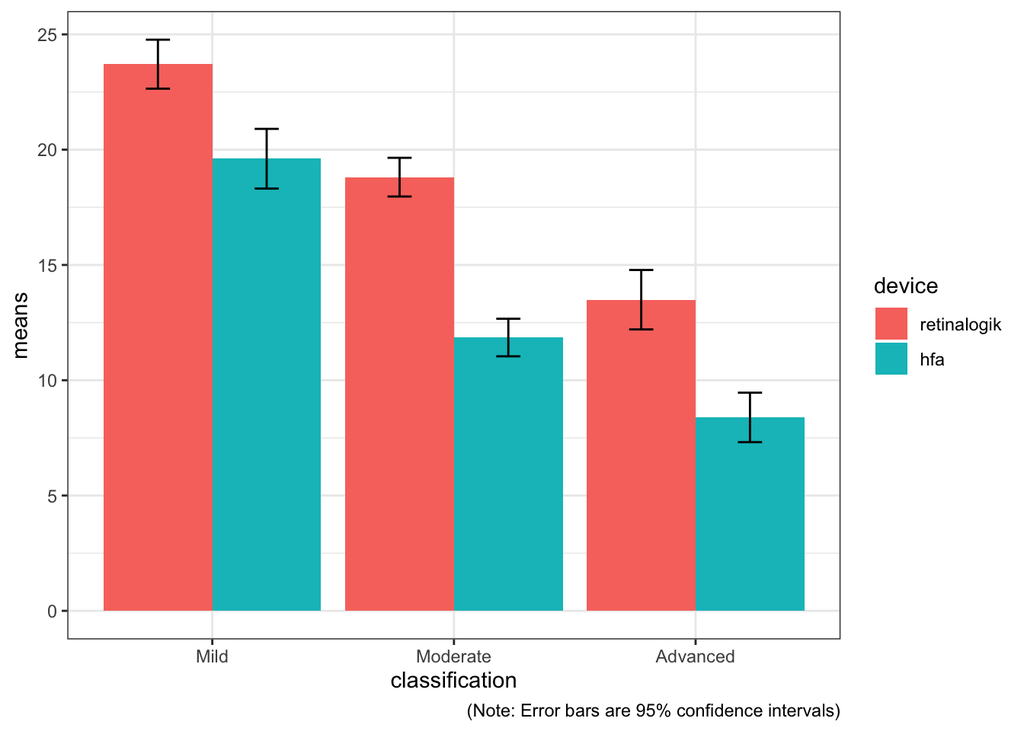

```r
scotoma_meansplot <- all_scotoma_points %>%
  pivot_longer(cols = c(retinalogik, hfa),
               names_to = "device",
               values_to = "dB") %>%
  group_by(classification, device) %>%
  summarise(n = n(),
            means = mean(dB),
            sd = sd(dB)) %>%
  mutate( se=sd/sqrt(n))  %>%
  mutate( ic=se * qt((1-0.05)/2 + .5, n-1)) %>%
  mutate(classification = factor(classification, levels=c('Mild','Moderate','Advanced')),
         device = factor(device, levels = c('retinalogik', 'hfa'))) %>%
  ggplot(aes(x=classification, y=means, fill=device)) +
  geom_bar(stat="identity", position=position_dodge()) +
  geom_errorbar(aes(ymin=means-ic, ymax=means+ic), width=.2,
                 position=position_dodge(.9)) +
  labs(caption = "(Note: Error bars are 95% confidence intervals)") +
  theme_bw()
> `summarise()` has regrouped the output.
> ℹ Summaries were computed grouped by classification and device.
> ℹ Output is grouped by classification.
> ℹ Use `summarise(.groups = "drop_last")` to silence this message.
> ℹ Use `summarise(.by = c(classification, device))` for per-operation grouping
>   (`?dplyr::dplyr_by`) instead.

scotoma_mediansplot <- all_scotoma_points %>%
  pivot_longer(cols = c(retinalogik, hfa),
               names_to = "device",
               values_to = "dB") %>%
  group_by(classification, device) %>%
  summarise(n = n(),
            medians = median(dB),
            q1 = quantile(dB, .25, na.rm = TRUE),
            q3 = quantile(dB, .75, na.rm = TRUE)) %>%
  mutate(classification = factor(classification, levels=c('Mild','Moderate','Advanced')),
         device = factor(device, levels = c('retinalogik', 'hfa'))) %>%
  ggplot(aes(x=classification, y=medians, fill=device)) +
  geom_bar(stat="identity", position=position_dodge()) +
  geom_errorbar(aes(ymin=q1, ymax=q3), width=.2,
                position=position_dodge(.9)) +
  annotate("text", x = "Mild", y = 30, label = "***", size = 8) +
  annotate("text", x = "Moderate", y = 28, label = "***", size = 8) +
  annotate("text", x = "Advanced", y = 22, label = "***", size = 8) +
  scale_x_discrete(labels = c("Mild" = "Early")) +
  labs(x = "Classification",
       y = "Medians",
       caption = "(Note: Error bars are IQR)") +
  ylim(c(-1, 35)) +  # Increased y-limit slightly to give the legend breathing room
  theme_bw() +
  scale_fill_grey(start = 0.9, end = 0.6,
                  labels = c("VR device", "HFA")) +
  theme(legend.position = c(0.85, 0.85), # Place inside top-right (Adjust as needed)
        legend.title = element_blank(),  # Optional: removes the "device" title for cleaner look
        legend.background = element_blank()) # Optional: makes legend transparent
> `summarise()` has regrouped the output.
> ℹ Summaries were computed grouped by classification and device.
> ℹ Output is grouped by classification.
> ℹ Use `summarise(.groups = "drop_last")` to silence this message.
> ℹ Use `summarise(.by = c(classification, device))` for per-operation grouping
>   (`?dplyr::dplyr_by`) instead.

scotoma_meansplot
```

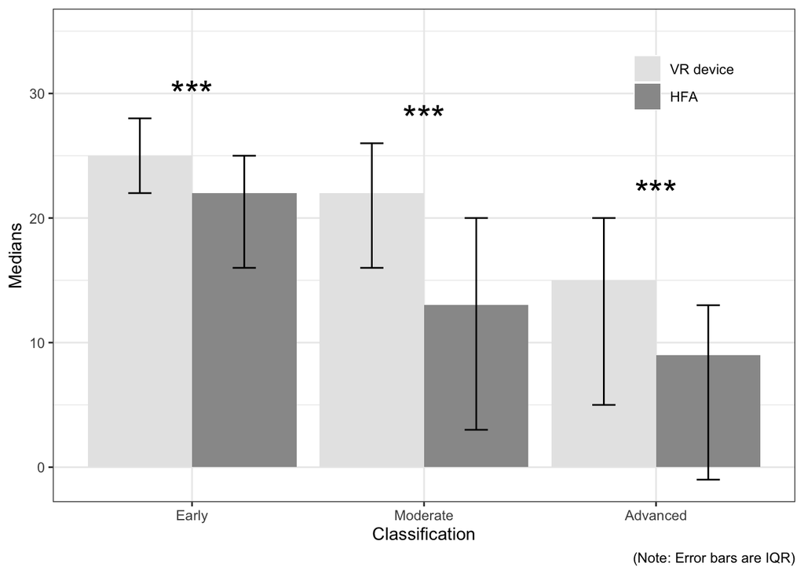

```r
scotoma_mediansplot
```

```r
ggsave("plots/scotoma_mediansplot.png")
> Saving 7 x 5 in image
```

### Plots for verification

```r
facet_labels <- c(
  "psd_p" = "HFA PSD p-values",
  "hfa" = "HFA",
  "retinalogik" = "VR device"
)

for (current_id in unique(long_data$id)) {
  cat(paste0("#### Patient ", current_id, "\n\n"))

  current_id_data <- long_data %>% filter(id == current_id)

  p <- create_vf_plot(current_id_data) +
    # Dynamic text color logic based on value threshold
    geom_text(aes(label = value,
                  color = ifelse(value < 7, "white", "black")),
              size = 3) +
    scale_color_identity() +
    # Facet configuration
    facet_grid(
      visit ~ measure,
      scales = "fixed",
      drop = FALSE,
      labeller = labeller(
        measure = as_labeller(facet_labels),
        visit   = as_labeller(function(x) paste("Visit", x))
      )
    )

  print(p)
  cat("\n\n")
}
```

#### Patient RL04

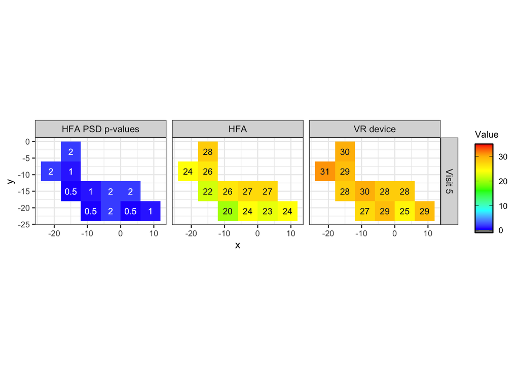

#### Patient RL10

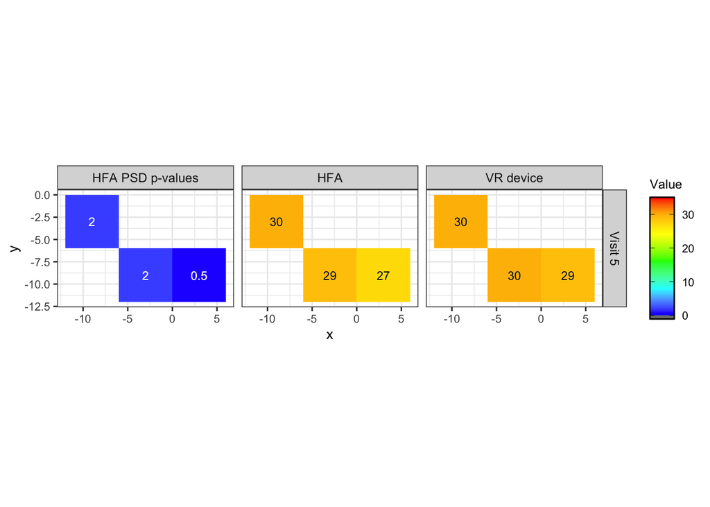

#### Patient RL15

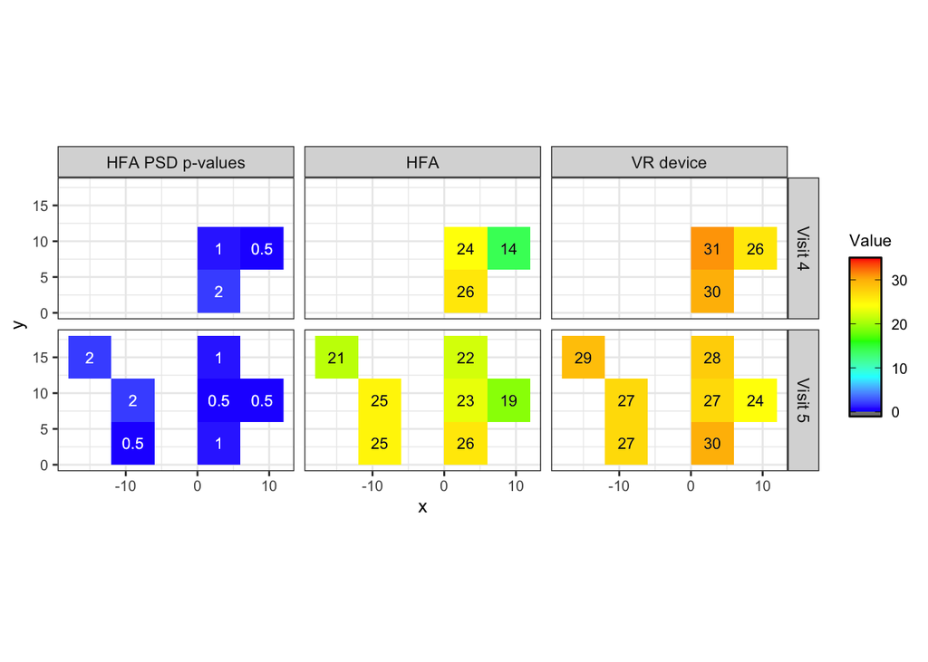

#### Patient RL17

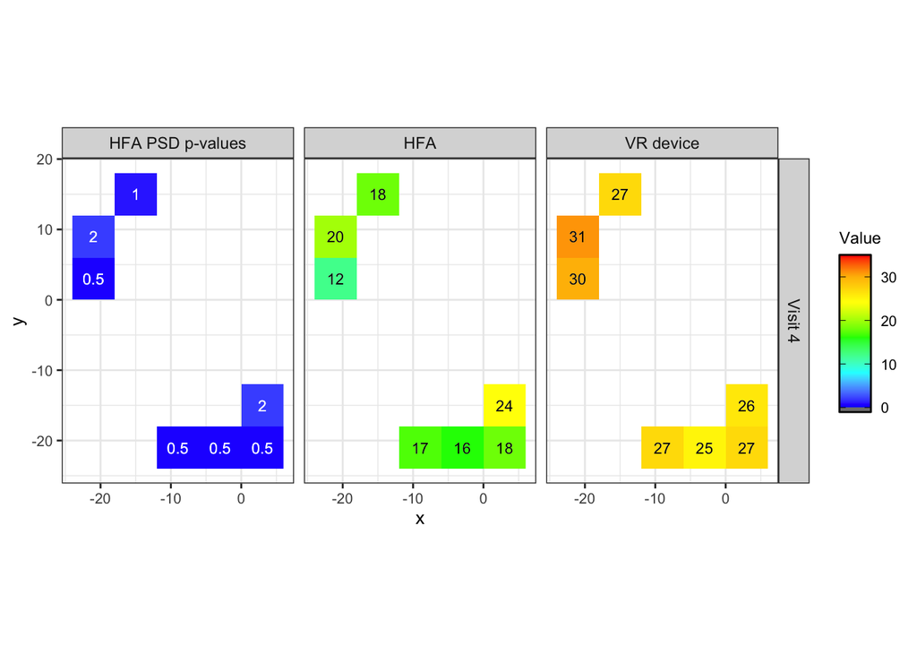

#### Patient RL19

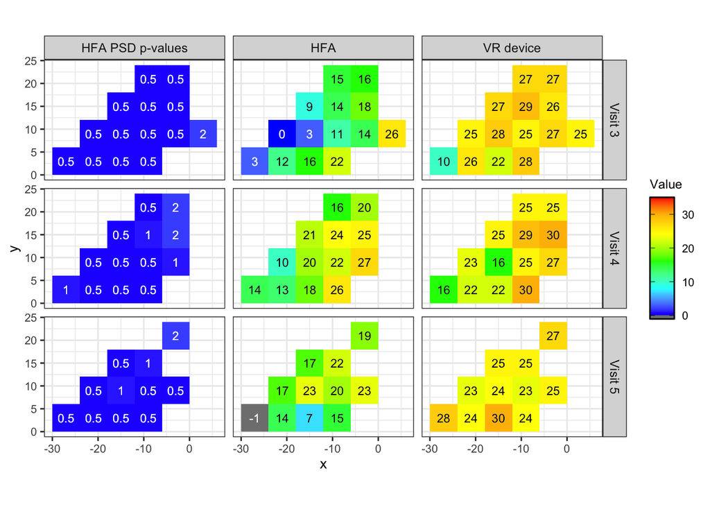

#### Patient RL21

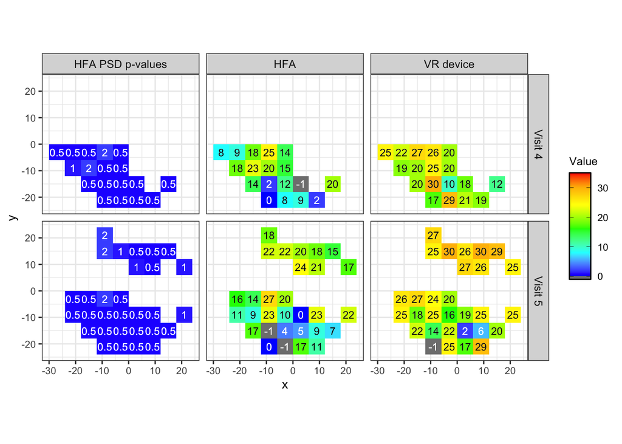

#### Patient RL22

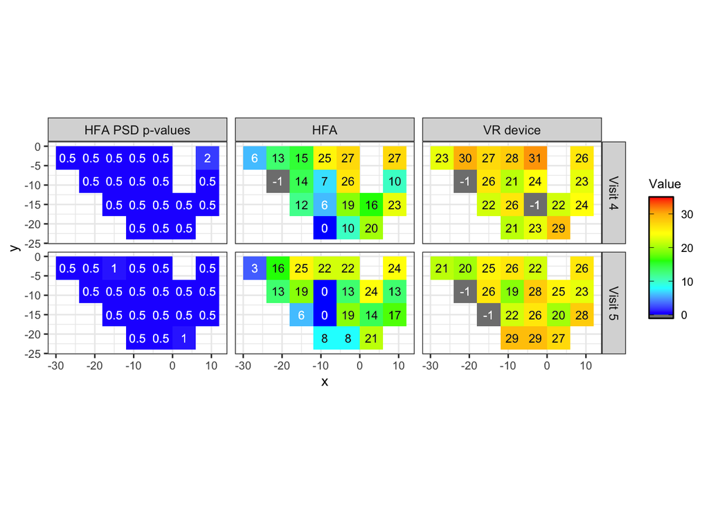

#### Patient RL23

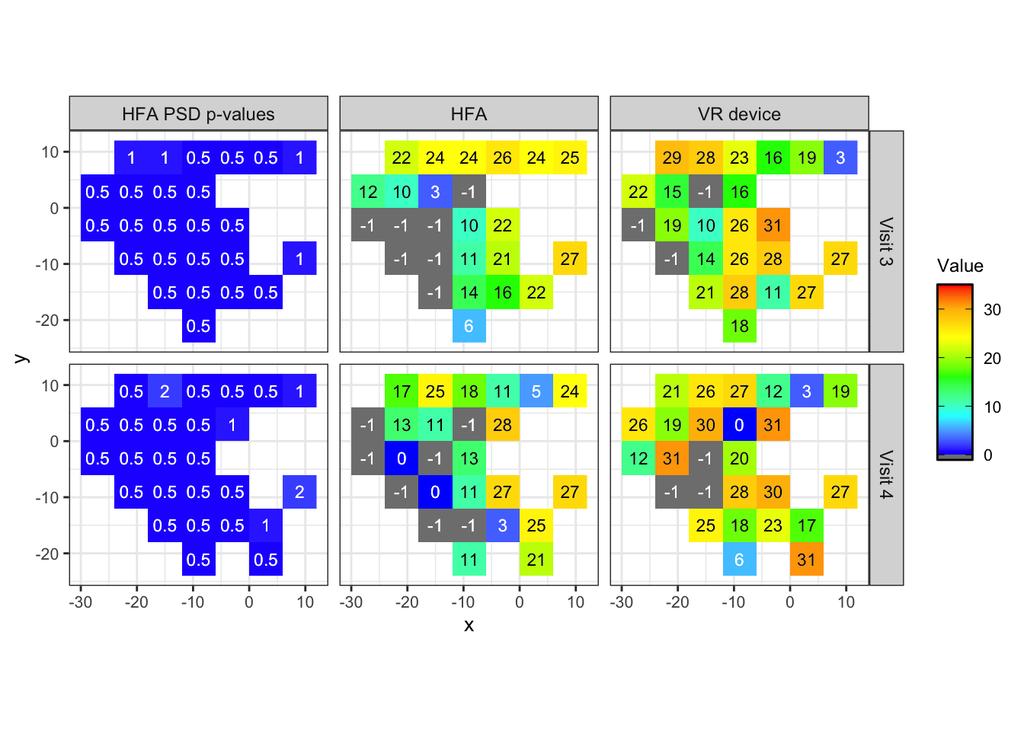

#### Patient RL24

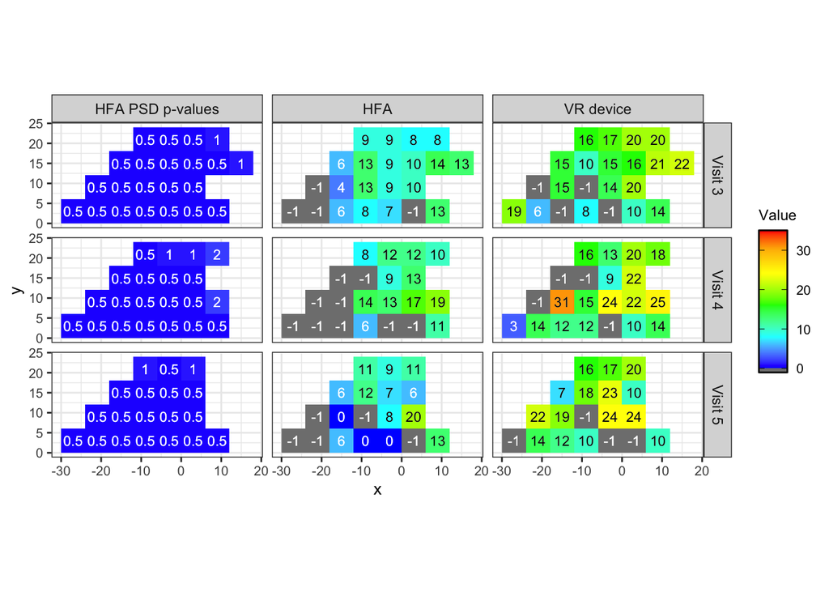

#### Patient RL27

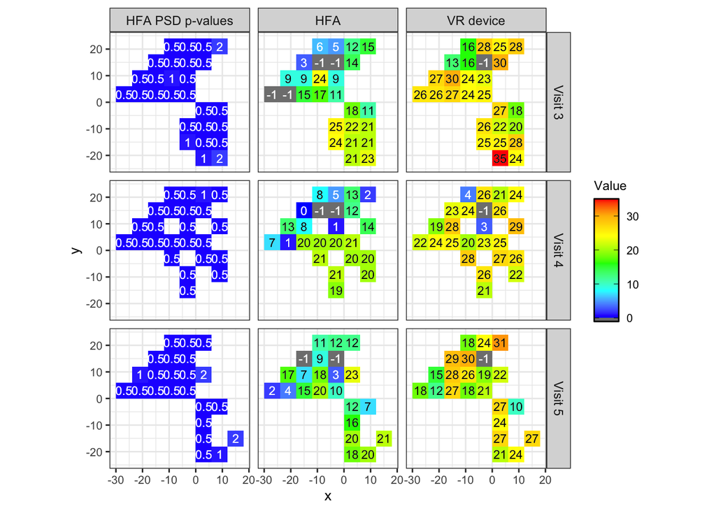

#### Patient RL32

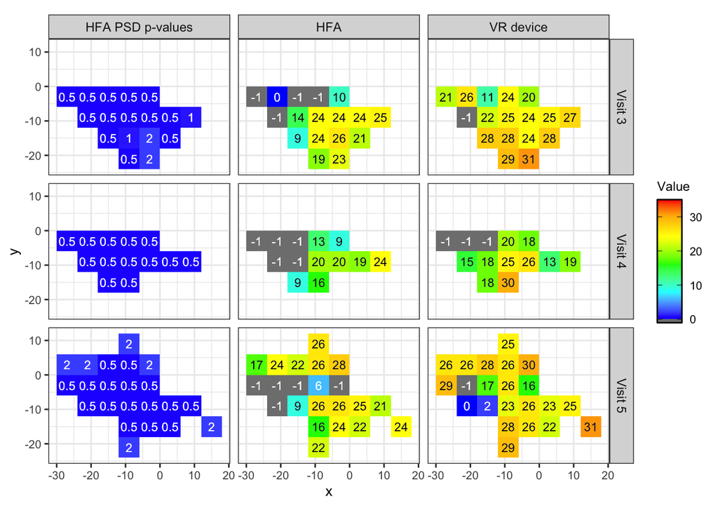

#### Patient RL33

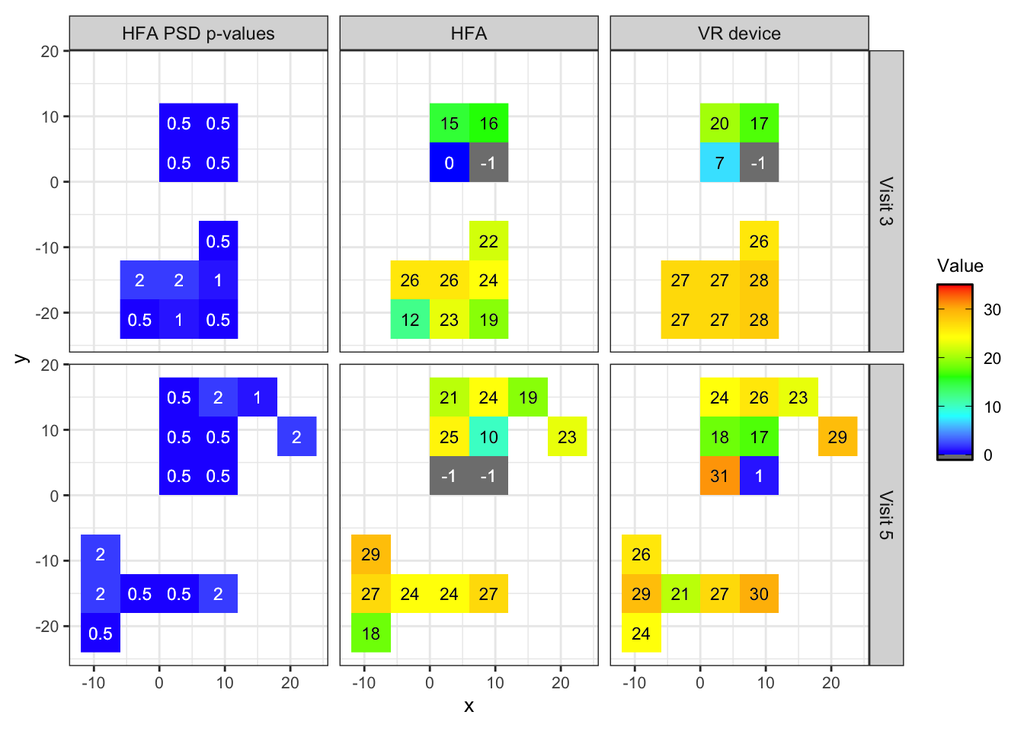

#### Patient RL35

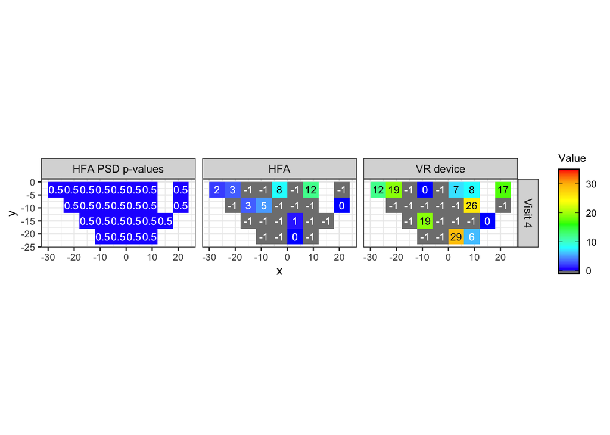

#### Patient RL40

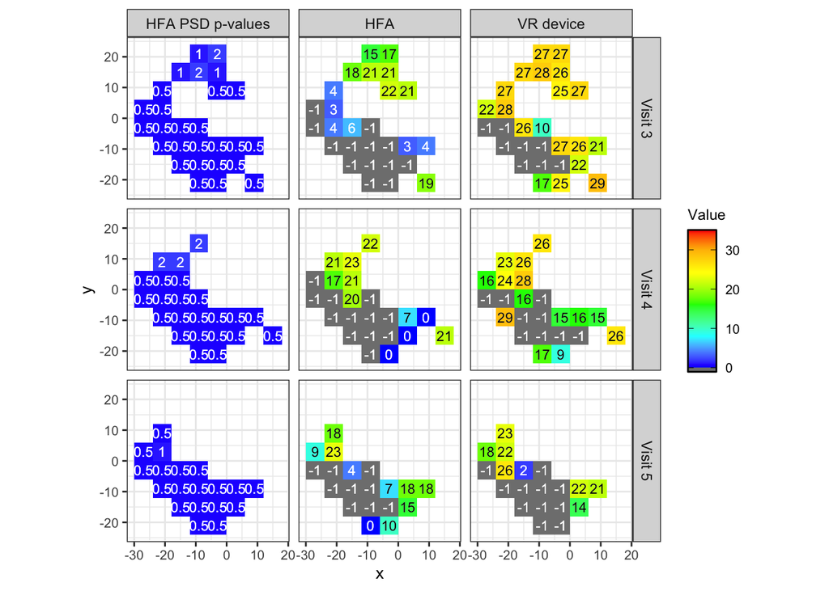

#### Patient RL42

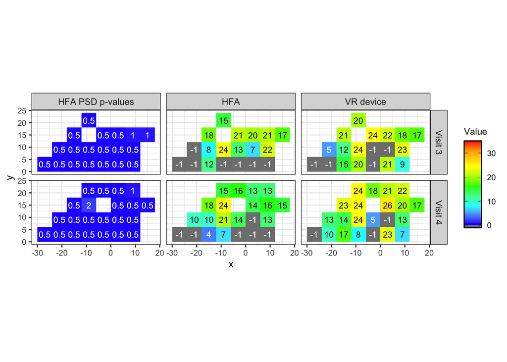

#### Patient RL51

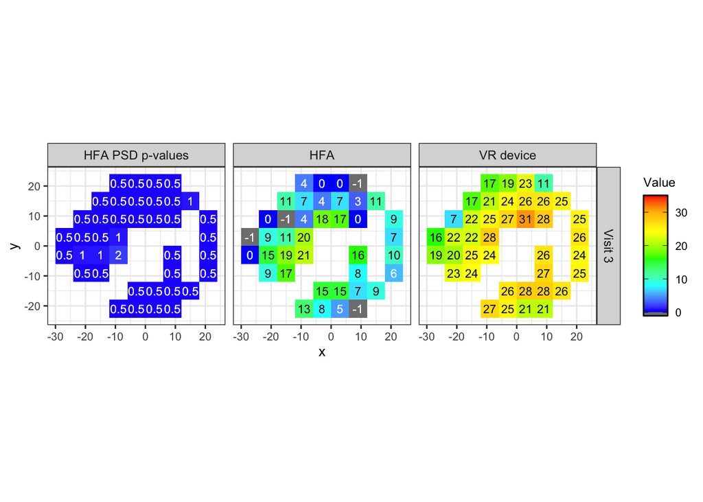

#### Patient RL52

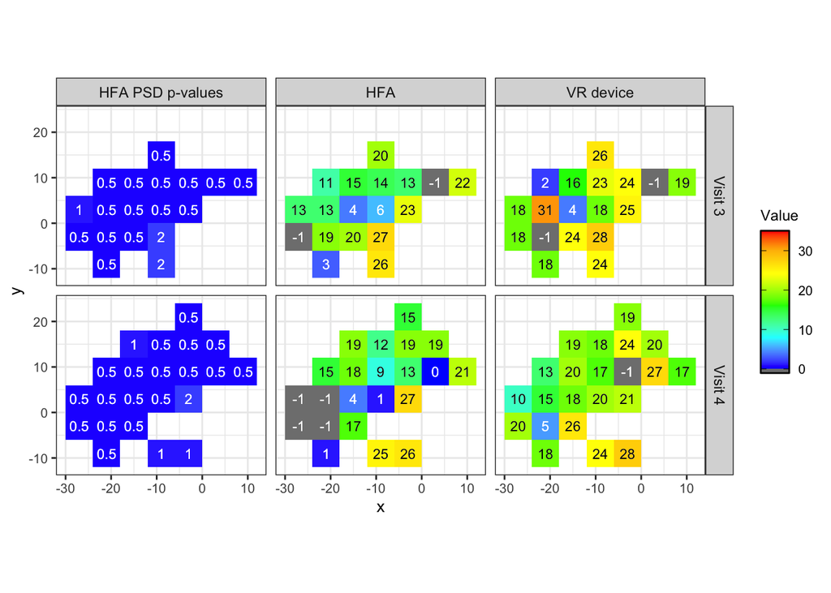

#### Patient RL56

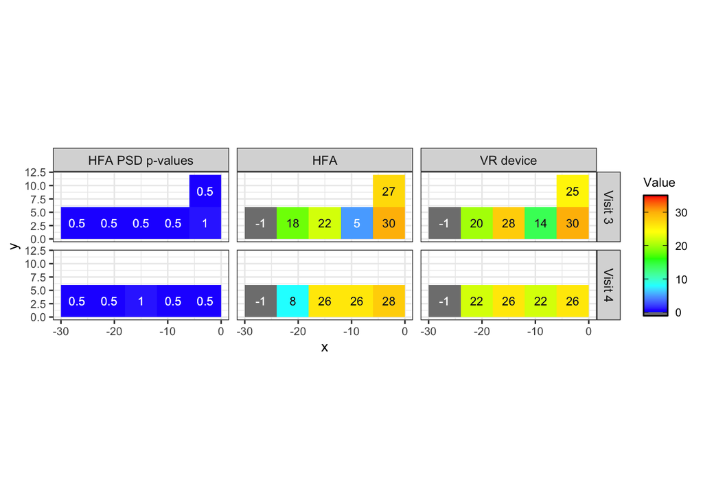

#### Patient RL57

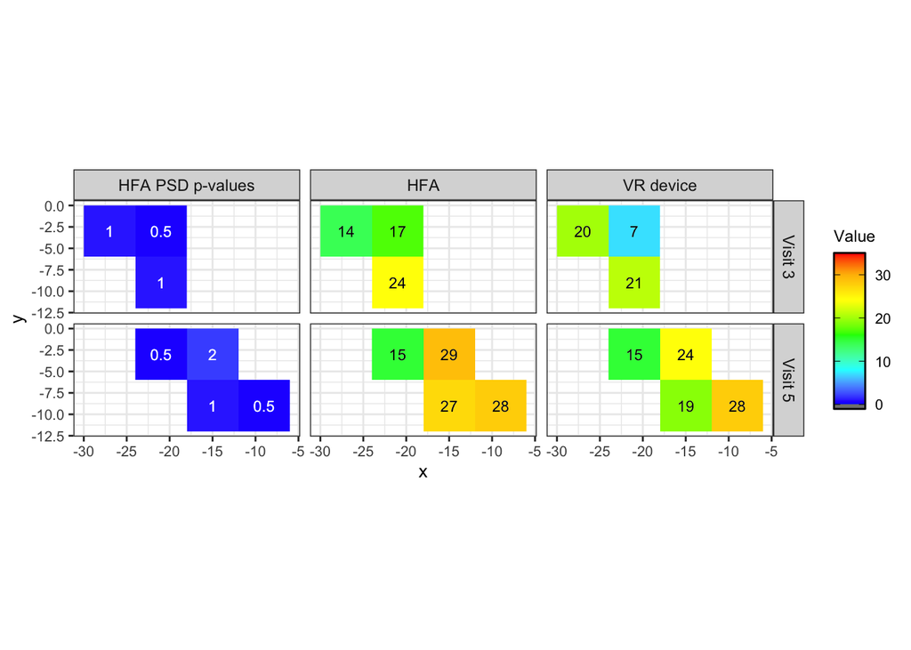

#### Patient RL58

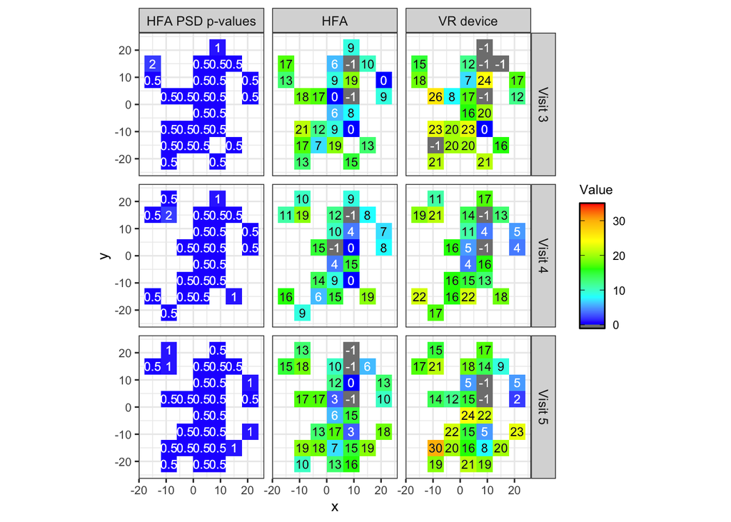

#### Patient RL60

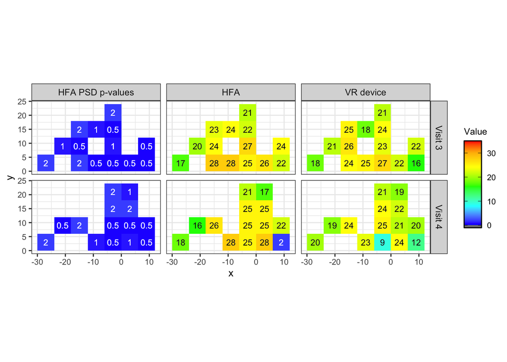

#### Patient RL62

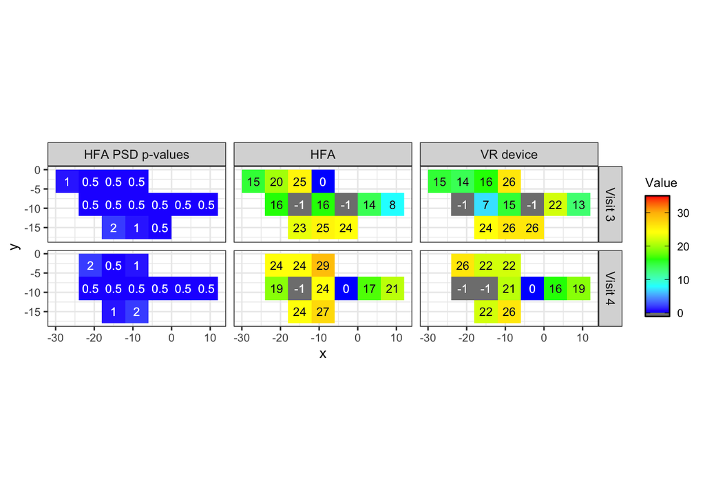

#### Patient RL64

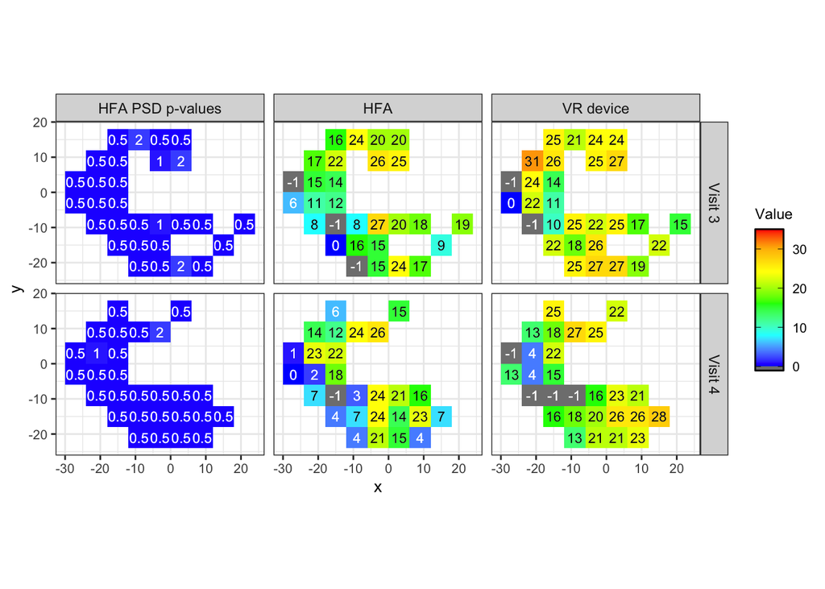

#### Patient RL65

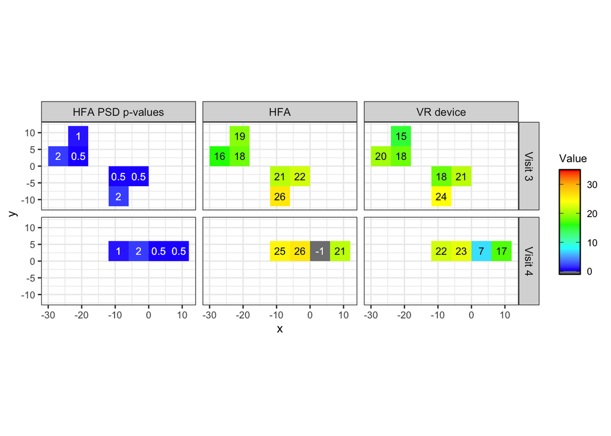

## One patient, all visits, no filters, right eye

```r
# --- Define the main analysis function ---
analyze_visual_field_data <- function(my_data_input, rttmp_raw_input) {

  # 1. Data Preparation and Spatial Object Creation
  # Create a clean psd_p column, treating NA as non-defective (e.g., value > 5)
  my_data_processed <- my_data_input %>%
    mutate(psd_p_clean = ifelse(is.na(psd_p), 100, psd_p))

  # Convert the data frame to an sf (simple features) object
  points_sf <- st_as_sf(my_data_processed, coords = c("x", "y"), crs = NA)

  # 2. Filtering Defective Points
  # Filter for points where psd_p is less than 5% (including 0.5% and 5.0%)
  filtered_points_sf <- points_sf %>%
    filter(psd_p_clean < 5)

  # Initialize outputs
  identified_scotomas_table_df <- data.frame(
    Scotoma_ID = integer(),
    Number_of_Points = integer(),
    Minimum_psd_p_percent = numeric(),
    Constituent_Points = character(),
    stringsAsFactors = FALSE
  )
  all_scotoma_points_for_plot <- data.frame()

  # Ensure there are defective points to analyze
  if (nrow(filtered_points_sf) > 0) {
    # 3. Connected Components Labeling using Distance-Based Neighbors
    # Create a spatial weights matrix based on distance for the filtered points
    # d1 = 0: minimum distance (points must be distinct)
    # d2 = 9: maximum distance (captures vertical, horizontal, and diagonal neighbors
    #         given your coordinate spacing of 6 units, sqrt(6^2 + 6^2) approx 8.485)
    filtered_neighbors <- dnearneigh(filtered_points_sf, d1 = 0, d2 = 9)

    # Check if there are any connections among the filtered points
    if (length(unlist(filtered_neighbors)) > 0) {
      # Find connected components (contiguous groups)
      components <- n.comp.nb(filtered_neighbors)

      # Assign component IDs back to the filtered data
      filtered_points_sf$component_id <- components$comp.id

      # 4. Filtering Connected Components by Scotoma Criteria
      scotomas_found <- list()
      unique_component_ids <- unique(filtered_points_sf$component_id)

      for (comp_id in unique_component_ids) {
        current_cluster <- filtered_points_sf %>%
          filter(component_id == comp_id)

        num_points <- nrow(current_cluster)
        # Check if any point in this cluster has psd_p < 1% (i.e., psd_p_clean == 0.5)
        has_p_lt_1_percent <- any(current_cluster$psd_p_clean < 1)

        # Apply scotoma definition: at least 3 points AND at least 1 location at p < 1%
        if (num_points >= 3 && has_p_lt_1_percent) {
          scotomas_found[[as.character(comp_id)]] <- current_cluster %>%
            # Extract x and y coordinates from the geometry column
            mutate(
              x_coord = st_coordinates(.)[, "X"],
              y_coord = st_coordinates(.)[, "Y"]
            ) %>%
            # Now select the desired columns, including the newly extracted x_coord and y_coord
            select(x_coord, y_coord, psd_p) %>%
            # Drop the geometry column as it's no longer needed for the table output
            st_drop_geometry() %>%
            # Rename x_coord and y_coord back to x and y for consistency with the table format
            rename(x = x_coord, y = y_coord)
        }
      }

      # Prepare results for the report table
      scotoma_results_list <- list()
      if (length(scotomas_found) > 0) {
        scotoma_id_counter <- 1
        for (scotoma_label in names(scotomas_found)) {
          scotoma_data <- scotomas_found[[scotoma_label]]
          num_points <- nrow(scotoma_data)
          min_psd_p_actual <- min(scotoma_data$psd_p, na.rm = TRUE) # Use original psd_p for reporting

          # Format constituent points string
          constituent_points_str <- paste(
            paste0("(", scotoma_data$x, ",", scotoma_data$y, ") [p=", scotoma_data$psd_p, "%]"),
            collapse = "; "
          )

          scotoma_results_list[[scotoma_id_counter]] <- data.frame(
            Scotoma_ID = scotoma_id_counter,
            Number_of_Points = num_points,
            Minimum_psd_p_percent = min_psd_p_actual,
            Constituent_Points = constituent_points_str,
            stringsAsFactors = FALSE
          )
          scotoma_id_counter <- scotoma_id_counter + 1
        }
      }

      # Final table of identified scotomas
      identified_scotomas_table_df <- if (length(scotoma_results_list) > 0) {
        do.call(rbind, scotoma_results_list)
      } else {
        data.frame(
          Scotoma_ID = integer(),
          Number_of_Points = integer(),
          Minimum_psd_p_percent = numeric(),
          Constituent_Points = character(),
          stringsAsFactors = FALSE
        )
      }

      # Prepare all scotoma points for plotting with a sequential ID
      if (length(scotomas_found) > 0) {
        scotoma_id_map <- 1
        for (original_comp_id in names(scotomas_found)) {
          temp_df <- scotomas_found[[original_comp_id]]
          temp_df$scotoma_plot_id <- scotoma_id_map # Assign a sequential ID for plotting colors
          all_scotoma_points_for_plot <- bind_rows(all_scotoma_points_for_plot, temp_df)
          scotoma_id_map <- scotoma_id_map + 1
        }
      }
    }
  }

  # Prepare data for Retinalogik dB plot
  # Filter rttmp_raw_input to only include points present in my_data_processed (50 points)
  rttmp_filtered_for_plot <- rttmp_raw_input %>%
    semi_join(my_data_processed, by = c("x", "y"))

  # Join filtered_rttmp with my_data_processed to get psd_p for coloring the background
  rttmp_for_plot_with_psdp <- rttmp_filtered_for_plot %>%
    left_join(my_data_processed %>% select(x, y, psd_p), by = c("x", "y"))

  return(list(
    scotoma_table = identified_scotomas_table_df,
    hfa_data_processed = my_data_processed,
    scotoma_points_for_plot = all_scotoma_points_for_plot,
    rttmp_data_for_plot = rttmp_for_plot_with_psdp
  ))
}

# --- Define plotting functions ---

generate_hfa_psd_plot <- function(hfa_data_processed) {
  customcolors <- brewer.pal(4, "YlOrRd")
  customcolors <- rev(customcolors)

  hfa_data_processed %>%
    ggplot(aes(x, y)) +
    geom_raster(aes(fill = factor(psd_p))) +
    geom_text(aes(label = ifelse(is.na(psd_p), "", psd_p)), size = 3) +
    coord_fixed(ratio = 1) +
    scale_fill_manual(values = customcolors, na.value = "gray") +
    theme_bw() +
    ggtitle("HFA", subtitle = "PSD p-values") +
    theme(legend.position = "none")
}

generate_hfa_db_plot <- function(hfa_data_processed) {
  customcolors <- brewer.pal(4, "YlOrRd")
  customcolors <- rev(customcolors)

  hfa_data_processed %>%
    ggplot(aes(x, y)) +
    geom_raster(aes(fill = factor(psd_p))) +
    geom_text(aes(label = ifelse(is.na(dB), "", dB)), size = 3) +
    coord_fixed(ratio = 1) +
    scale_fill_manual(values = customcolors, na.value = "gray") +
    theme_bw() +
    ggtitle("HFA", subtitle = "Threshold sensitivity dB values") +
    theme(legend.position = "none")
}

generate_scotoma_highlight_plot <- function(hfa_data_processed, scotoma_points_for_plot) {
  ggplot() +
    geom_point(data = hfa_data_processed, aes(x = x, y = y), color = "grey", size = 1, alpha = 0.5) +
    {
      if (nrow(scotoma_points_for_plot) > 0) {
        list(
          geom_point(data = scotoma_points_for_plot,
                     aes(x = x, y = y, color = as.factor(scotoma_plot_id)),
                     size = 3, shape = 16),
          scale_color_viridis_d(option = "viridis", name = "Scotoma ID"),
          geom_point(data = scotoma_points_for_plot,
                     aes(x = x, y = y),
                     color = "black", size = 5, shape = 1)
        )
      }
    } +
    labs(title = "Identified Scotomas on Visual Field",
         x = "X-coordinate (degrees)", y = "Y-coordinate (degrees)") +
    theme_minimal() +
    theme(legend.position = "right")
}

generate_retinalogik_plot <- function(rttmp_data_for_plot) {
  retinalogik_colors <- rev(brewer.pal(3, "YlOrRd"))

  rttmp_data_for_plot %>%
    ggplot(aes(x, y)) +
    geom_raster(aes(fill = factor(psd_p))) +
    geom_text(aes(label = ifelse(is.na(dB), "", dB)), size = 3) +
    coord_fixed(ratio = 1) +
    scale_fill_manual(values = retinalogik_colors, na.value = "gray") +
    theme_bw() +
    ggtitle("Retinalogik", subtitle = "Threshold sensitivity dB values") +
    theme(legend.position = "none")
}
```

### RL35

#### Visit 1

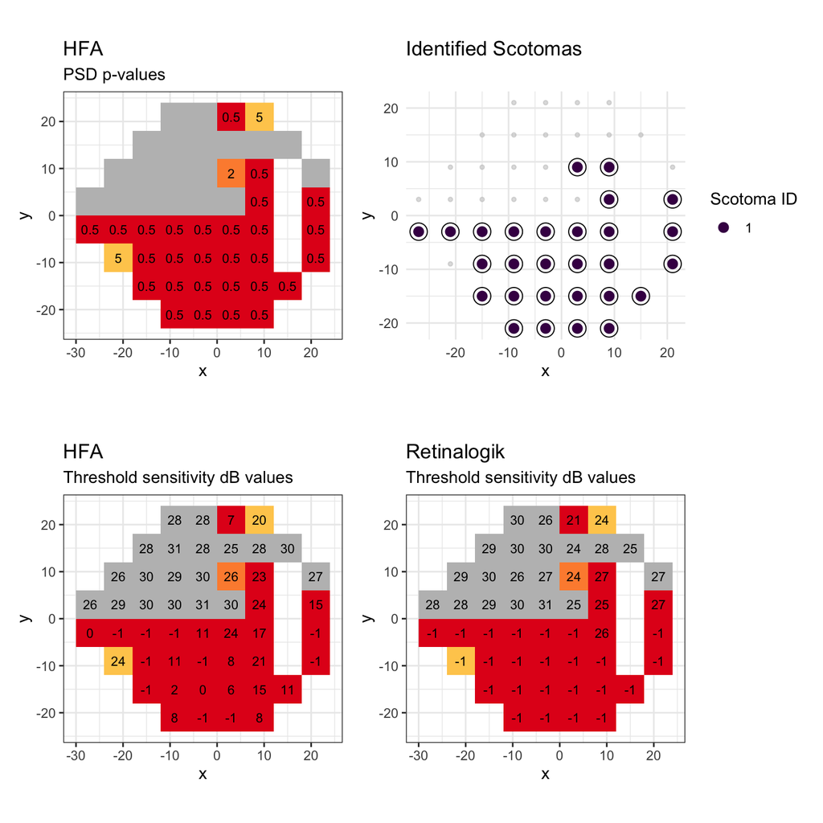

```r
# require(sf)
# require(spdep)
# require(patchwork)

# remove locations directly above and below blindspots
psdpvalues_hfa <- alldat %>%
  filter(!(x==15 & y==9) & !(x==15 & y==-9))

# remove reliability indices <30%
psdpvalues_hfa <- psdpvalues_hfa %>%
  filter((fl/flTest) < 0.3 & fnPerc < 0.3 & fpPerc < 0.3)

tmp <- psdpvalues_hfa %>%
  filter(id=="RL35" & eye=="R")

customcolors <- brewer.pal(4, "YlOrRd")
customcolors <- rev(customcolors)

my_data <- psdpvalues_hfa %>%
  filter(datetime==ymd_hms("2025-05-20 09:48:31 ") & eye=="R")

rttmp <- dBdat %>%
  filter(id=="RL35", visit==1, eye=="R", device=="retinalogik") %>%
  select(id, eye, x, y, dB)

# 1. Data Preparation and Binary Grid Creation
my_data_processed <- my_data %>%
  mutate(psd_p_clean = ifelse(is.na(psd_p), 100, psd_p))

# Convert the data frame to an sf (simple features) object
points_sf <- st_as_sf(my_data_processed, coords = c("x", "y"), crs = NA)

# 2. Filtering Defective Points
# Filter for points where psd_p is less than 5% (including 0.5% and 5.0%)
filtered_points_sf <- points_sf %>%
  filter(psd_p_clean < 5)

# Ensure there are defective points to analyze
if (nrow(filtered_points_sf) > 0) {
  # 3. Connected Components Labeling using Distance-Based Neighbors
  # Create a spatial weights matrix based on distance for the filtered points
  # d1 = 0: minimum distance (points must be distinct)
  # d2 = 9: maximum distance (captures vertical, horizontal, and diagonal neighbors
  #         given your coordinate spacing of 6 units, sqrt(6^2 + 6^2) approx 8.485)
  filtered_neighbors <- dnearneigh(filtered_points_sf, d1 = 0, d2 = 9)

  # Check if there are any connections among the filtered points
  if (length(unlist(filtered_neighbors)) > 0) {
    # Find connected components (contiguous groups)
    components <- n.comp.nb(filtered_neighbors)

    # Assign component IDs back to the filtered data
    filtered_points_sf$component_id <- components$comp.id

    # 4. Filtering Connected Components by Scotoma Criteria
    scotomas_found <- list()
    unique_component_ids <- unique(filtered_points_sf$component_id)

    for (comp_id in unique_component_ids) {
      current_cluster <- filtered_points_sf %>%
        filter(component_id == comp_id)

      num_points <- nrow(current_cluster)
      # Check if any point in this cluster has psd_p < 1% (i.e., psd_p_clean == 0.5)
      has_p_lt_1_percent <- any(current_cluster$psd_p_clean < 1)

      # Apply scotoma definition: at least 3 points AND at least 1 location at p < 1%
      # Apply scotoma definition: at least 3 points AND at least 1 location at p < 1%
      if (num_points >= 3 && has_p_lt_1_percent) {
        scotomas_found[[as.character(comp_id)]] <- current_cluster %>%
          # Extract x and y coordinates from the geometry column
          mutate(
            x_coord = st_coordinates(.)[, "X"],
            y_coord = st_coordinates(.)[, "Y"]
          ) %>%
          # Now select the desired columns, including the newly extracted x_coord and y_coord
          select(x_coord, y_coord, psd_p) %>%
          # Drop the geometry column as it's no longer needed for the table output
          st_drop_geometry() %>%
          # Rename x_coord and y_coord back to x and y for consistency with the table format
          rename(x = x_coord, y = y_coord)
      }
    }

    # Prepare results for the report table
    scotoma_results_list <- list()
    if (length(scotomas_found) > 0) {
      scotoma_id_counter <- 1
      for (scotoma_label in names(scotomas_found)) {
        scotoma_data <- scotomas_found[[scotoma_label]]
        num_points <- nrow(scotoma_data)
        min_psd_p_actual <- min(scotoma_data$psd_p, na.rm = TRUE) # Use original psd_p for reporting

        # Format constituent points string
        constituent_points_str <- paste(
          paste0("(", scotoma_data$x, ",", scotoma_data$y, ") [p=", scotoma_data$psd_p, "%]"),
          collapse = "; "
        )

        scotoma_results_list[[scotoma_id_counter]] <- data.frame(
          Scotoma_ID = scotoma_id_counter,
          Number_of_Points = num_points,
          Minimum_psd_p_percent = min_psd_p_actual,
          Constituent_Points = constituent_points_str,
          stringsAsFactors = FALSE
        )
        scotoma_id_counter <- scotoma_id_counter + 1
      }
    }

    # Final table of identified scotomas
    identified_scotomas_table_df <- if (length(scotoma_results_list) > 0) {
      do.call(rbind, scotoma_results_list)
    } else {
      data.frame(
        Scotoma_ID = integer(),
        Number_of_Points = integer(),
        Minimum_psd_p_percent = numeric(),
        Constituent_Points = character(),
        stringsAsFactors = FALSE
      )
    }

  } else {
    identified_scotomas_table_df <- data.frame(
      Scotoma_ID = integer(),
      Number_of_Points = integer(),
      Minimum_psd_p_percent = numeric(),
      Constituent_Points = character(),
      stringsAsFactors = FALSE
    )
  }
} else {
  identified_scotomas_table_df <- data.frame(
    Scotoma_ID = integer(),
    Number_of_Points = integer(),
    Minimum_psd_p_percent = numeric(),
    Constituent_Points = character(),
    stringsAsFactors = FALSE
  )
}

# Print the table (for verification within the R environment)
print(identified_scotomas_table_df)
>   Scotoma_ID Number_of_Points Minimum_psd_p_percent
> 1          1               28                   0.5
>                                                                                                                                                                                                                                                                                                                                                                                                                                                                                                     Constituent_Points
> 1 (-15,-15) [p=0.5%]; (-15,-3) [p=0.5%]; (-15,-9) [p=0.5%]; (-21,-3) [p=0.5%]; (-27,-3) [p=0.5%]; (-3,-15) [p=0.5%]; (-3,-21) [p=0.5%]; (-3,-3) [p=0.5%]; (-3,-9) [p=0.5%]; (-9,-15) [p=0.5%]; (-9,-21) [p=0.5%]; (-9,-3) [p=0.5%]; (-9,-9) [p=0.5%]; (15,-15) [p=0.5%]; (21,-3) [p=0.5%]; (21,-9) [p=0.5%]; (21,3) [p=0.5%]; (3,-15) [p=0.5%]; (3,-21) [p=0.5%]; (3,-3) [p=0.5%]; (3,-9) [p=0.5%]; (3,9) [p=2%]; (9,-15) [p=0.5%]; (9,-21) [p=0.5%]; (9,-3) [p=0.5%]; (9,-9) [p=0.5%]; (9,3) [p=0.5%]; (9,9) [p=0.5%]

# Define custom colors for psd_p values for the background raster
customcolors <- brewer.pal(4, "YlOrRd")
customcolors <- rev(customcolors)

# Plot 1: HFA Pattern Deviation Probability Plot (similar to user's 'p' plot)
# This plot shows the psd_p values for all test points.
p_plot <- my_data_processed %>%
  ggplot(aes(x, y)) +
  geom_raster(aes(fill = factor(psd_p))) + # Use original psd_p for fill
  geom_text(aes(label = ifelse(is.na(psd_p), "", psd_p)), size = 3) +
  coord_fixed(ratio = 1) +
  scale_fill_manual(values = customcolors, na.value = "gray") +
  theme_bw() +
  ggtitle("HFA", subtitle = "PSD p-values") +
  theme(legend.position = "none")

dB_plot <- my_data_processed %>%
  ggplot(aes(x, y)) +
  geom_raster(aes(fill = factor(psd_p))) + # Use original psd_p for fill
  geom_text(aes(label = ifelse(is.na(dB), "", dB)), size = 3) +
  coord_fixed(ratio = 1) +
  scale_fill_manual(values = customcolors, na.value = "gray") +
  theme_bw() +
  ggtitle("HFA", subtitle = "Threshold sensitivity dB values") +
  theme(legend.position = "none")

rttmp_filtered_for_plot <- rttmp %>%
  semi_join(my_data_processed, by = c("x", "y"))

# Join filtered_rttmp with my_data_processed to get psd_p for coloring the background
rttmp_for_plot_with_psdp <- rttmp_filtered_for_plot %>%
  left_join(my_data_processed %>% select(x, y, psd_p), by = c("x", "y"))

# Plot 4: Retinalogik Threshold Sensitivity dB values
rt_plot <- rttmp_for_plot_with_psdp %>%
  ggplot(aes(x, y)) +
  geom_raster(aes(fill = factor(psd_p))) + # Use HFA psd_p for fill as per user's example
  geom_text(aes(label = ifelse(is.na(dB), "", dB)), size = 3) + # Use Retinalogik dB for label
  coord_fixed(ratio = 1) +
  scale_fill_manual(values = customcolors, na.value = "gray") +
  theme_bw() +
  ggtitle("Retinalogik", subtitle = "Threshold sensitivity dB values") +
  theme(legend.position = "none")

# Prepare data for the scotoma highlight plot
# Combine all identified scotoma points into a single data frame for plotting
all_scotoma_points_for_plot <- data.frame()
if (length(scotomas_found) > 0) {
  scotoma_id_map <- 1
  for (original_comp_id in names(scotomas_found)) {
    temp_df <- scotomas_found[[original_comp_id]]
    temp_df$scotoma_plot_id <- scotoma_id_map # Assign a sequential ID for plotting colors
    all_scotoma_points_for_plot <- bind_rows(all_scotoma_points_for_plot, temp_df)
    scotoma_id_map <- scotoma_id_map + 1
  }
}

# Plot 2: Identified Scotomas Highlighted (similar to user's 'plot_scotoma')
# This plot overlays the identified scotoma points on a grey background of all points.
plot_scotoma_highlight <- ggplot() +
  geom_point(data = my_data_processed, aes(x = x, y = y), color = "grey", size = 1, alpha = 0.5) + # All points as background
  {
    if (nrow(all_scotoma_points_for_plot) > 0) {
      list(
        geom_point(data = all_scotoma_points_for_plot,
                   aes(x = x, y = y, color = as.factor(scotoma_plot_id)),
                   size = 3, shape = 16), # Highlight scotoma points
        scale_color_viridis_d(option = "viridis", name = "Scotoma ID"), # Use viridis for distinct scotoma colors
        geom_point(data = all_scotoma_points_for_plot,
                   aes(x = x, y = y),
                   color = "black", size = 5, shape = 1) # Add black outline for emphasis
      )
    }
  } +
  labs(title = "Identified Scotomas",
       x = "x", y = "y") +
  theme_minimal() +
  theme(legend.position = "right")

(p_plot + plot_scotoma_highlight)/
  (dB_plot + rt_plot)
```

#### Visit 2

```r
tmp <- psdpvalues_hfa %>%
  filter(id=="35" & eye=="R")

my_data <- psdpvalues_hfa %>%
  filter(datetime==ymd_hms("2025-05-22 09:40:31") & eye=="R")

customcolors <- brewer.pal(4, "YlOrRd")
customcolors <- rev(customcolors)

p <- my_data %>%
  ggplot(aes(x, y, psd_p)) +
  geom_raster(aes(x = x, y = y, fill = factor(psd_p))) +
  geom_text(aes(label = ifelse(is.na(psd_p), "", psd_p),
                x = x, y = y), size = 3) +
  coord_fixed(ratio = 1) +
  scale_fill_manual(values = customcolors, na.value="gray") +
  theme_bw() +
  ggtitle("HFA", subtitle = "PSD p-values") +
  theme(legend.position="none")

dBplot <- my_data %>%
  ggplot(aes(x, y, psd_p, dB)) +
  geom_raster(aes(x = x, y = y, fill = factor(psd_p))) +
  geom_text(aes(label = dB, x = x, y = y), size = 3) +
  coord_fixed(ratio = 1) +
  scale_fill_manual(values = customcolors, na.value="gray") +
  theme_bw() +
  ggtitle("HFA", subtitle = "Threshold sensitivity dB values") +
  theme(legend.position="none")

my_sf <- my_data %>%
  select(datetime, eye, id, x, y, dB, psd_p) %>%
  st_as_sf(coords = c("x", "y"), crs = NA)

# You can view the data
#plot(my_sf)

# Convert to sf object
# It's good practice to provide a CRS if your coordinates represent real-world locations.
# For simple relative coordinates, NA is fine.
points_sf <- st_as_sf(my_sf, wkt = "geometry", crs = NA)

# Create a spatial weights matrix based on distance for point data
# d1 = 0: minimum distance (points must be distinct)
# d2 = 9: maximum distance (captures vertical, horizontal, and diagonal neighbors
#         given your coordinate spacing of 6 units)
neighbors <- dnearneigh(points_sf, d1 = 0, d2 = 9)

# Convert the neighbor list to a spatial weights list (binary style is common)
weights_list <- nb2listw(neighbors, style = "B")

# Filter for points where psd_p <= 5
# Using is.finite() to handle NA values in psd_p, as NA <= 5 would also be NA, not FALSE.
filtered_points <- points_sf %>%
  filter(is.finite(psd_p) & psd_p <= 5)

if(nrow(filtered_points) > 0) {
  # Create a spatial weights matrix for the filtered points (re-evaluate neighbors)
  # This ensures we only consider contiguity among the *filtered* points.
  filtered_neighbors <- dnearneigh(filtered_points, d1 = 0, d2 = 9)

  # Check if there are any connections among the filtered points
  if (length(unlist(filtered_neighbors)) > 0) { # Check if any neighbors exist
    # Find connected components (contiguous groups)
    components <- n.comp.nb(filtered_neighbors)

    # Assign component IDs back to the filtered data
    filtered_points$component_id <- components$comp.id

    # Group by component and count points
    contiguous_groups <- filtered_points %>%
      group_by(component_id) %>%
      summarize(n_points = n()) %>%
      arrange(desc(n_points))

    # Print the results
    #print("Contiguous groups where psd_p <= 5:")
    #print(contiguous_groups)

    # Find the largest contiguous group
    largest_group_id <- contiguous_groups$component_id[1]

    largest_group <- filtered_points %>%
      filter(component_id == largest_group_id)

    #print("Largest Contiguous Group:")
    #print(largest_group)

    if (nrow(largest_group) >= 3) {
      #print("Largest contiguous group has at least 3 points.")
      # Optionally, extract and print the coordinates of the largest group
      #print("Coordinates of the largest contiguous group:")
      #print(st_coordinates(largest_group))
    } else {
      #print("No contiguous group with at least 3 points found that has at least 3 points.")
    }
  } else {
    #print("No contiguous points found after filtering for psd_p <= 5.")
  }

} else {
  #print("No points found where psd_p <= 5.")
}
> NULL

# --- Visualization ---

# Plot all original points
# plot_all_points <- ggplot() +
#   geom_sf(data = points_sf, color = "grey", size = 1, alpha = 0.5) +
#   labs(title = "All Original Points (Grey) and Filtered Contiguous Groups (Colored)",
#        x = "X-coordinate", y = "Y-coordinate") +
#   theme_minimal()

plot_all_points <- ggplot() +
  geom_sf(data = points_sf, color = "grey", size = 1, alpha = 0.5) +
  labs(title = "Contiguous Groups",
       x = "x", y = "y") +
  theme_bw()

# Add the filtered and grouped points on top, colored by their component_id
# Use a specific color palette if you have many groups
plot_scotoma <- plot_all_points +
  geom_sf(data = filtered_points, aes(color = as.factor(component_id)), size = 3) +
  scale_color_viridis_d(option = "viridis", name = "Contiguous Group ID") # Viridis is a good perceptually uniform palette

# Highlight the largest contiguous group
# (Optional: you can make these points larger or a different shape)
plot_scotoma <- plot_scotoma +
  geom_sf(data = largest_group, color = "black", size = 5) +
  theme(legend.position="none")

# Print the plot
#print(plot_all_points)

rttmp <- dBdat %>%
  filter(id=="RL35", visit==2, eye=="R", device=="retinalogik") %>%
  select(id, eye, x, y, dB)

hfatmp <- largest_group %>%
  mutate(x = st_coordinates(.)[, "X"],
         y = st_coordinates(.)[, "Y"]) %>%
  st_drop_geometry()

mergeddat <- left_join(rttmp, hfatmp, by=c("id","eye","x","y")) %>%
  # remove blindspots and locations directly above and below blindspots
  # remove locations directly above and below blindspots
  filter(!(x==15 & y==3) & !(x==15 & y==-3) & !(x==15 & y==9) & !(x==15 & y==-9))

mergeddat <- mergeddat %>%
  merge(my_data, by=c("id","eye","x","y","psd_p"))

rtplot <- mergeddat %>%
  ggplot(aes(x, y, psd_p, dB.x)) +
  geom_raster(aes(x = x, y = y, fill = factor(psd_p))) +
  geom_text(aes(label = dB.x, x = x, y = y), size = 3) +
  coord_fixed(ratio = 1) +
  scale_fill_manual(values = rev(brewer.pal(3, "YlOrRd")), na.value="gray") +
  theme_bw() +
  ggtitle("Retinalogik", subtitle = "Threshold sensitivity dB values") +
  theme(legend.position="none")

hfaplot <- mergeddat %>%
  ggplot(aes(x, y, psd_p, dB)) +
  geom_raster(aes(x = x, y = y, fill = factor(psd_p))) +
  geom_text(aes(label = dB, x = x, y = y), size = 3) +
  coord_fixed(ratio = 1) +
  scale_fill_manual(values = rev(brewer.pal(3, "YlOrRd")), na.value="gray") +
  theme_bw() +
  ggtitle("HFA", subtitle = "Threshold sensitivity dB values") +
  theme(legend.position="none")
```

```r
# mergeddat %>%
#   ggplot(aes(x, y, psd_p)) +
#   geom_raster(aes(x = x, y = y, fill = factor(psd_p))) +
#   geom_text(aes(label = psd_p, x = x, y = y), size = 3) +
#   coord_fixed(ratio = 1) +
#   scale_fill_manual(values = customcolors, na.value="gray") +
#   theme_bw() +
#   ggtitle("Retinalogik", subtitle = "Threshold sensitivity dB values") +
#   theme(legend.position="none")

#(p + plot_scotoma) / (hfaplot + rtplot)

# 1. Data Preparation and Binary Grid Creation
my_data_processed <- my_data %>%
  mutate(psd_p_clean = ifelse(is.na(psd_p), 100, psd_p))

# Convert the data frame to an sf (simple features) object
points_sf <- st_as_sf(my_data_processed, coords = c("x", "y"), crs = NA)

# 2. Filtering Defective Points
# Filter for points where psd_p is less than 5% (including 0.5% and 5.0%)
filtered_points_sf <- points_sf %>%
  filter(psd_p_clean < 5)

# Ensure there are defective points to analyze
if (nrow(filtered_points_sf) > 0) {
  # 3. Connected Components Labeling using Distance-Based Neighbors
  # Create a spatial weights matrix based on distance for the filtered points
  # d1 = 0: minimum distance (points must be distinct)
  # d2 = 9: maximum distance (captures vertical, horizontal, and diagonal neighbors
  #         given your coordinate spacing of 6 units, sqrt(6^2 + 6^2) approx 8.485)
  filtered_neighbors <- dnearneigh(filtered_points_sf, d1 = 0, d2 = 9)

  # Check if there are any connections among the filtered points
  if (length(unlist(filtered_neighbors)) > 0) {
    # Find connected components (contiguous groups)
    components <- n.comp.nb(filtered_neighbors)

    # Assign component IDs back to the filtered data
    filtered_points_sf$component_id <- components$comp.id

    # 4. Filtering Connected Components by Scotoma Criteria
    scotomas_found <- list()
    unique_component_ids <- unique(filtered_points_sf$component_id)

    for (comp_id in unique_component_ids) {
      current_cluster <- filtered_points_sf %>%
        filter(component_id == comp_id)

      num_points <- nrow(current_cluster)
      # Check if any point in this cluster has psd_p < 1% (i.e., psd_p_clean == 0.5)
      has_p_lt_1_percent <- any(current_cluster$psd_p_clean < 1)

      # Apply scotoma definition: at least 3 points AND at least 1 location at p < 1%
      # Apply scotoma definition: at least 3 points AND at least 1 location at p < 1%
      if (num_points >= 3 && has_p_lt_1_percent) {
        scotomas_found[[as.character(comp_id)]] <- current_cluster %>%
          # Extract x and y coordinates from the geometry column
          mutate(
            x_coord = st_coordinates(.)[, "X"],
            y_coord = st_coordinates(.)[, "Y"]
          ) %>%
          # Now select the desired columns, including the newly extracted x_coord and y_coord
          select(x_coord, y_coord, psd_p) %>%
          # Drop the geometry column as it's no longer needed for the table output
          st_drop_geometry() %>%
          # Rename x_coord and y_coord back to x and y for consistency with the table format
          rename(x = x_coord, y = y_coord)
      }
    }

    # Prepare results for the report table
    scotoma_results_list <- list()
    if (length(scotomas_found) > 0) {
      scotoma_id_counter <- 1
      for (scotoma_label in names(scotomas_found)) {
        scotoma_data <- scotomas_found[[scotoma_label]]
        num_points <- nrow(scotoma_data)
        min_psd_p_actual <- min(scotoma_data$psd_p, na.rm = TRUE) # Use original psd_p for reporting

        # Format constituent points string
        constituent_points_str <- paste(
          paste0("(", scotoma_data$x, ",", scotoma_data$y, ") [p=", scotoma_data$psd_p, "%]"),
          collapse = "; "
        )

        scotoma_results_list[[scotoma_id_counter]] <- data.frame(
          Scotoma_ID = scotoma_id_counter,
          Number_of_Points = num_points,
          Minimum_psd_p_percent = min_psd_p_actual,
          Constituent_Points = constituent_points_str,
          stringsAsFactors = FALSE
        )
        scotoma_id_counter <- scotoma_id_counter + 1
      }
    }

    # Final table of identified scotomas
    identified_scotomas_table_df <- if (length(scotoma_results_list) > 0) {
      do.call(rbind, scotoma_results_list)
    } else {
      data.frame(
        Scotoma_ID = integer(),
        Number_of_Points = integer(),
        Minimum_psd_p_percent = numeric(),
        Constituent_Points = character(),
        stringsAsFactors = FALSE
      )
    }

  } else {
    identified_scotomas_table_df <- data.frame(
      Scotoma_ID = integer(),
      Number_of_Points = integer(),
      Minimum_psd_p_percent = numeric(),
      Constituent_Points = character(),
      stringsAsFactors = FALSE
    )
  }
} else {
  identified_scotomas_table_df <- data.frame(
    Scotoma_ID = integer(),
    Number_of_Points = integer(),
    Minimum_psd_p_percent = numeric(),
    Constituent_Points = character(),
    stringsAsFactors = FALSE
  )
}

# Print the table (for verification within the R environment)
print(identified_scotomas_table_df)
>   Scotoma_ID Number_of_Points Minimum_psd_p_percent
> 1          1               27                   0.5
> 2          2                3                   0.5
>                                                                                                                                                                                                                                                                                                                                                                                                                                                                                        Constituent_Points
> 1 (-15,-15) [p=0.5%]; (-15,-3) [p=0.5%]; (-15,-9) [p=0.5%]; (-21,-3) [p=0.5%]; (-21,-9) [p=0.5%]; (-27,-3) [p=0.5%]; (-3,-15) [p=0.5%]; (-3,-21) [p=0.5%]; (-3,-3) [p=0.5%]; (-3,-9) [p=0.5%]; (-9,-15) [p=0.5%]; (-9,-21) [p=0.5%]; (-9,-3) [p=0.5%]; (-9,-9) [p=0.5%]; (15,-15) [p=0.5%]; (21,-3) [p=0.5%]; (21,-9) [p=0.5%]; (21,3) [p=0.5%]; (3,-15) [p=0.5%]; (3,-21) [p=0.5%]; (3,-3) [p=0.5%]; (3,-9) [p=0.5%]; (9,-15) [p=0.5%]; (9,-21) [p=0.5%]; (9,-3) [p=0.5%]; (9,-9) [p=0.5%]; (9,3) [p=1%]
> 2                                                                                                                                                                                                                                                                                                                                                                                                                                                       (3,21) [p=0.5%]; (9,15) [p=0.5%]; (9,21) [p=0.5%]
```

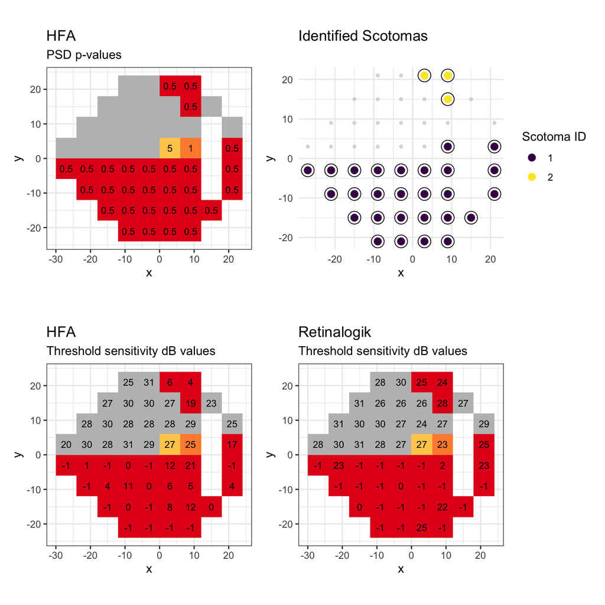

```r
# Define custom colors for psd_p values for the background raster
customcolors <- brewer.pal(4, "YlOrRd")
customcolors <- rev(customcolors)

# Plot 1: HFA Pattern Deviation Probability Plot (similar to user's 'p' plot)
# This plot shows the psd_p values for all test points.
p_plot <- my_data_processed %>%
  ggplot(aes(x, y)) +
  geom_raster(aes(fill = factor(psd_p))) + # Use original psd_p for fill
  geom_text(aes(label = ifelse(is.na(psd_p), "", psd_p)), size = 3) +
  coord_fixed(ratio = 1) +
  scale_fill_manual(values = customcolors, na.value = "gray") +
  theme_bw() +
  ggtitle("HFA", subtitle = "PSD p-values") +
  theme(legend.position = "none")

dB_plot <- my_data_processed %>%
  ggplot(aes(x, y)) +
  geom_raster(aes(fill = factor(psd_p))) + # Use original psd_p for fill
  geom_text(aes(label = ifelse(is.na(dB), "", dB)), size = 3) +
  coord_fixed(ratio = 1) +
  scale_fill_manual(values = customcolors, na.value = "gray") +
  theme_bw() +
  ggtitle("HFA", subtitle = "Threshold sensitivity dB values") +
  theme(legend.position = "none")

rttmp_filtered_for_plot <- rttmp %>%
  semi_join(my_data_processed, by = c("x", "y"))

# Join filtered_rttmp with my_data_processed to get psd_p for coloring the background
rttmp_for_plot_with_psdp <- rttmp_filtered_for_plot %>%
  left_join(my_data_processed %>% select(x, y, psd_p), by = c("x", "y"))

# Plot 4: Retinalogik Threshold Sensitivity dB values
rt_plot <- rttmp_for_plot_with_psdp %>%
  ggplot(aes(x, y)) +
  geom_raster(aes(fill = factor(psd_p))) + # Use HFA psd_p for fill as per user's example
  geom_text(aes(label = ifelse(is.na(dB), "", dB)), size = 3) + # Use Retinalogik dB for label
  coord_fixed(ratio = 1) +
  scale_fill_manual(values = customcolors, na.value = "gray") +
  theme_bw() +
  ggtitle("Retinalogik", subtitle = "Threshold sensitivity dB values") +
  theme(legend.position = "none")

# Prepare data for the scotoma highlight plot
# Combine all identified scotoma points into a single data frame for plotting
all_scotoma_points_for_plot <- data.frame()
if (length(scotomas_found) > 0) {
  scotoma_id_map <- 1
  for (original_comp_id in names(scotomas_found)) {
    temp_df <- scotomas_found[[original_comp_id]]
    temp_df$scotoma_plot_id <- scotoma_id_map # Assign a sequential ID for plotting colors
    all_scotoma_points_for_plot <- bind_rows(all_scotoma_points_for_plot, temp_df)
    scotoma_id_map <- scotoma_id_map + 1
  }
}

# Plot 2: Identified Scotomas Highlighted (similar to user's 'plot_scotoma')
# This plot overlays the identified scotoma points on a grey background of all points.
plot_scotoma_highlight <- ggplot() +
  geom_point(data = my_data_processed, aes(x = x, y = y), color = "grey", size = 1, alpha = 0.5) + # All points as background
  {
    if (nrow(all_scotoma_points_for_plot) > 0) {
      list(
        geom_point(data = all_scotoma_points_for_plot,
                   aes(x = x, y = y, color = as.factor(scotoma_plot_id)),
                   size = 3, shape = 16), # Highlight scotoma points
        scale_color_viridis_d(option = "viridis", name = "Scotoma ID"), # Use viridis for distinct scotoma colors
        geom_point(data = all_scotoma_points_for_plot,
                   aes(x = x, y = y),
                   color = "black", size = 5, shape = 1) # Add black outline for emphasis
      )
    }
  } +
  labs(title = "Identified Scotomas",
       x = "x", y = "y") +
  theme_minimal() +
  theme(legend.position = "right")

# To display these plots in your R environment, you would use:
# print(p_plot)
# print(plot_scotoma_highlight)
# If you have the 'patchwork' package installed, you can combine them like:
# library(patchwork)
(p_plot + plot_scotoma_highlight)/
  (dB_plot + rt_plot)
```

#### Visit 3

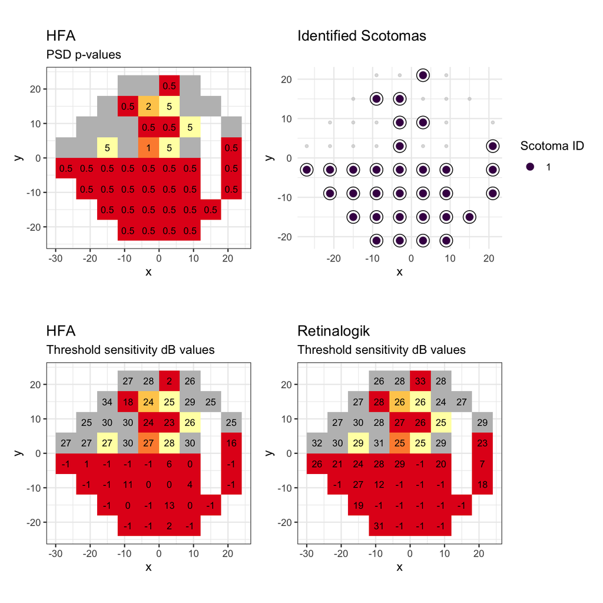

```r
my_data <- psdpvalues_hfa %>%
  filter(datetime==ymd_hms("2025-05-23 10:00:11") & eye=="R")

rttmp <- dBdat %>%
  filter(id=="RL35", visit==3, eye=="R", device=="retinalogik") %>%
  select(id, eye, x, y, dB)

# 1. Data Preparation and Binary Grid Creation
my_data_processed <- my_data %>%
  mutate(psd_p_clean = ifelse(is.na(psd_p), 100, psd_p))

# Convert the data frame to an sf (simple features) object
points_sf <- st_as_sf(my_data_processed, coords = c("x", "y"), crs = NA)

# 2. Filtering Defective Points
# Filter for points where psd_p is less than 5% (including 0.5% and 5.0%)
filtered_points_sf <- points_sf %>%
  filter(psd_p_clean < 5)

# Ensure there are defective points to analyze
if (nrow(filtered_points_sf) > 0) {
  # 3. Connected Components Labeling using Distance-Based Neighbors
  # Create a spatial weights matrix based on distance for the filtered points
  # d1 = 0: minimum distance (points must be distinct)
  # d2 = 9: maximum distance (captures vertical, horizontal, and diagonal neighbors
  #         given your coordinate spacing of 6 units, sqrt(6^2 + 6^2) approx 8.485)
  filtered_neighbors <- dnearneigh(filtered_points_sf, d1 = 0, d2 = 9)

  # Check if there are any connections among the filtered points
  if (length(unlist(filtered_neighbors)) > 0) {
    # Find connected components (contiguous groups)
    components <- n.comp.nb(filtered_neighbors)

    # Assign component IDs back to the filtered data
    filtered_points_sf$component_id <- components$comp.id

    # 4. Filtering Connected Components by Scotoma Criteria
    scotomas_found <- list()
    unique_component_ids <- unique(filtered_points_sf$component_id)

    for (comp_id in unique_component_ids) {
      current_cluster <- filtered_points_sf %>%
        filter(component_id == comp_id)

      num_points <- nrow(current_cluster)
      # Check if any point in this cluster has psd_p < 1% (i.e., psd_p_clean == 0.5)
      has_p_lt_1_percent <- any(current_cluster$psd_p_clean < 1)

      # Apply scotoma definition: at least 3 points AND at least 1 location at p < 1%
      # Apply scotoma definition: at least 3 points AND at least 1 location at p < 1%
      if (num_points >= 3 && has_p_lt_1_percent) {
        scotomas_found[[as.character(comp_id)]] <- current_cluster %>%
          # Extract x and y coordinates from the geometry column
          mutate(
            x_coord = st_coordinates(.)[, "X"],
            y_coord = st_coordinates(.)[, "Y"]
          ) %>%
          # Now select the desired columns, including the newly extracted x_coord and y_coord
          select(x_coord, y_coord, psd_p) %>%
          # Drop the geometry column as it's no longer needed for the table output
          st_drop_geometry() %>%
          # Rename x_coord and y_coord back to x and y for consistency with the table format
          rename(x = x_coord, y = y_coord)
      }
    }

    # Prepare results for the report table
    scotoma_results_list <- list()
    if (length(scotomas_found) > 0) {
      scotoma_id_counter <- 1
      for (scotoma_label in names(scotomas_found)) {
        scotoma_data <- scotomas_found[[scotoma_label]]
        num_points <- nrow(scotoma_data)
        min_psd_p_actual <- min(scotoma_data$psd_p, na.rm = TRUE) # Use original psd_p for reporting

        # Format constituent points string
        constituent_points_str <- paste(
          paste0("(", scotoma_data$x, ",", scotoma_data$y, ") [p=", scotoma_data$psd_p, "%]"),
          collapse = "; "
        )

        scotoma_results_list[[scotoma_id_counter]] <- data.frame(
          Scotoma_ID = scotoma_id_counter,
          Number_of_Points = num_points,
          Minimum_psd_p_percent = min_psd_p_actual,
          Constituent_Points = constituent_points_str,
          stringsAsFactors = FALSE
        )
        scotoma_id_counter <- scotoma_id_counter + 1
      }
    }

    # Final table of identified scotomas
    identified_scotomas_table_df <- if (length(scotoma_results_list) > 0) {
      do.call(rbind, scotoma_results_list)
    } else {
      data.frame(
        Scotoma_ID = integer(),
        Number_of_Points = integer(),
        Minimum_psd_p_percent = numeric(),
        Constituent_Points = character(),
        stringsAsFactors = FALSE
      )
    }

  } else {
    identified_scotomas_table_df <- data.frame(
      Scotoma_ID = integer(),
      Number_of_Points = integer(),
      Minimum_psd_p_percent = numeric(),
      Constituent_Points = character(),
      stringsAsFactors = FALSE
    )
  }
} else {
  identified_scotomas_table_df <- data.frame(
    Scotoma_ID = integer(),
    Number_of_Points = integer(),
    Minimum_psd_p_percent = numeric(),
    Constituent_Points = character(),
    stringsAsFactors = FALSE
  )
}

# Print the table (for verification within the R environment)
print(identified_scotomas_table_df)
>   Scotoma_ID Number_of_Points Minimum_psd_p_percent
> 1          1               32                   0.5
>                                                                                                                                                                                                                                                                                                                                                                                                                                                                                                                                                                             Constituent_Points
> 1 (-15,-15) [p=0.5%]; (-15,-3) [p=0.5%]; (-15,-9) [p=0.5%]; (-21,-3) [p=0.5%]; (-21,-9) [p=0.5%]; (-27,-3) [p=0.5%]; (-3,-15) [p=0.5%]; (-3,-21) [p=0.5%]; (-3,-3) [p=0.5%]; (-3,-9) [p=0.5%]; (-3,15) [p=2%]; (-3,3) [p=1%]; (-3,9) [p=0.5%]; (-9,-15) [p=0.5%]; (-9,-21) [p=0.5%]; (-9,-3) [p=0.5%]; (-9,-9) [p=0.5%]; (-9,15) [p=0.5%]; (15,-15) [p=0.5%]; (21,-3) [p=0.5%]; (21,-9) [p=0.5%]; (21,3) [p=0.5%]; (3,-15) [p=0.5%]; (3,-21) [p=0.5%]; (3,-3) [p=0.5%]; (3,-9) [p=0.5%]; (3,21) [p=0.5%]; (3,9) [p=0.5%]; (9,-15) [p=0.5%]; (9,-21) [p=0.5%]; (9,-3) [p=0.5%]; (9,-9) [p=0.5%]

# Define custom colors for psd_p values for the background raster
customcolors <- brewer.pal(4, "YlOrRd")
customcolors <- rev(customcolors)

# Plot 1: HFA Pattern Deviation Probability Plot (similar to user's 'p' plot)
# This plot shows the psd_p values for all test points.
p_plot <- my_data_processed %>%
  ggplot(aes(x, y)) +
  geom_raster(aes(fill = factor(psd_p))) + # Use original psd_p for fill
  geom_text(aes(label = ifelse(is.na(psd_p), "", psd_p)), size = 3) +
  coord_fixed(ratio = 1) +
  scale_fill_manual(values = customcolors, na.value = "gray") +
  theme_bw() +
  ggtitle("HFA", subtitle = "PSD p-values") +
  theme(legend.position = "none")

dB_plot <- my_data_processed %>%
  ggplot(aes(x, y)) +
  geom_raster(aes(fill = factor(psd_p))) + # Use original psd_p for fill
  geom_text(aes(label = ifelse(is.na(dB), "", dB)), size = 3) +
  coord_fixed(ratio = 1) +
  scale_fill_manual(values = customcolors, na.value = "gray") +
  theme_bw() +
  ggtitle("HFA", subtitle = "Threshold sensitivity dB values") +
  theme(legend.position = "none")

rttmp_filtered_for_plot <- rttmp %>%
  semi_join(my_data_processed, by = c("x", "y"))

# Join filtered_rttmp with my_data_processed to get psd_p for coloring the background
rttmp_for_plot_with_psdp <- rttmp_filtered_for_plot %>%
  left_join(my_data_processed %>% select(x, y, psd_p), by = c("x", "y"))

# Plot 4: Retinalogik Threshold Sensitivity dB values
rt_plot <- rttmp_for_plot_with_psdp %>%
  ggplot(aes(x, y)) +
  geom_raster(aes(fill = factor(psd_p))) + # Use HFA psd_p for fill as per user's example
  geom_text(aes(label = ifelse(is.na(dB), "", dB)), size = 3) + # Use Retinalogik dB for label
  coord_fixed(ratio = 1) +
  scale_fill_manual(values = customcolors, na.value = "gray") +
  theme_bw() +
  ggtitle("Retinalogik", subtitle = "Threshold sensitivity dB values") +
  theme(legend.position = "none")

# Prepare data for the scotoma highlight plot
# Combine all identified scotoma points into a single data frame for plotting
all_scotoma_points_for_plot <- data.frame()
if (length(scotomas_found) > 0) {
  scotoma_id_map <- 1
  for (original_comp_id in names(scotomas_found)) {
    temp_df <- scotomas_found[[original_comp_id]]
    temp_df$scotoma_plot_id <- scotoma_id_map # Assign a sequential ID for plotting colors
    all_scotoma_points_for_plot <- bind_rows(all_scotoma_points_for_plot, temp_df)
    scotoma_id_map <- scotoma_id_map + 1
  }
}

# Plot 2: Identified Scotomas Highlighted (similar to user's 'plot_scotoma')
# This plot overlays the identified scotoma points on a grey background of all points.
plot_scotoma_highlight <- ggplot() +
  geom_point(data = my_data_processed, aes(x = x, y = y), color = "grey", size = 1, alpha = 0.5) + # All points as background
  {
    if (nrow(all_scotoma_points_for_plot) > 0) {
      list(
        geom_point(data = all_scotoma_points_for_plot,
                   aes(x = x, y = y, color = as.factor(scotoma_plot_id)),
                   size = 3, shape = 16), # Highlight scotoma points
        scale_color_viridis_d(option = "viridis", name = "Scotoma ID"), # Use viridis for distinct scotoma colors
        geom_point(data = all_scotoma_points_for_plot,
                   aes(x = x, y = y),
                   color = "black", size = 5, shape = 1) # Add black outline for emphasis
      )
    }
  } +
  labs(title = "Identified Scotomas",
       x = "x", y = "y") +
  theme_minimal() +
  theme(legend.position = "right")

(p_plot + plot_scotoma_highlight)/
  (dB_plot + rt_plot)
```

#### Visit 4

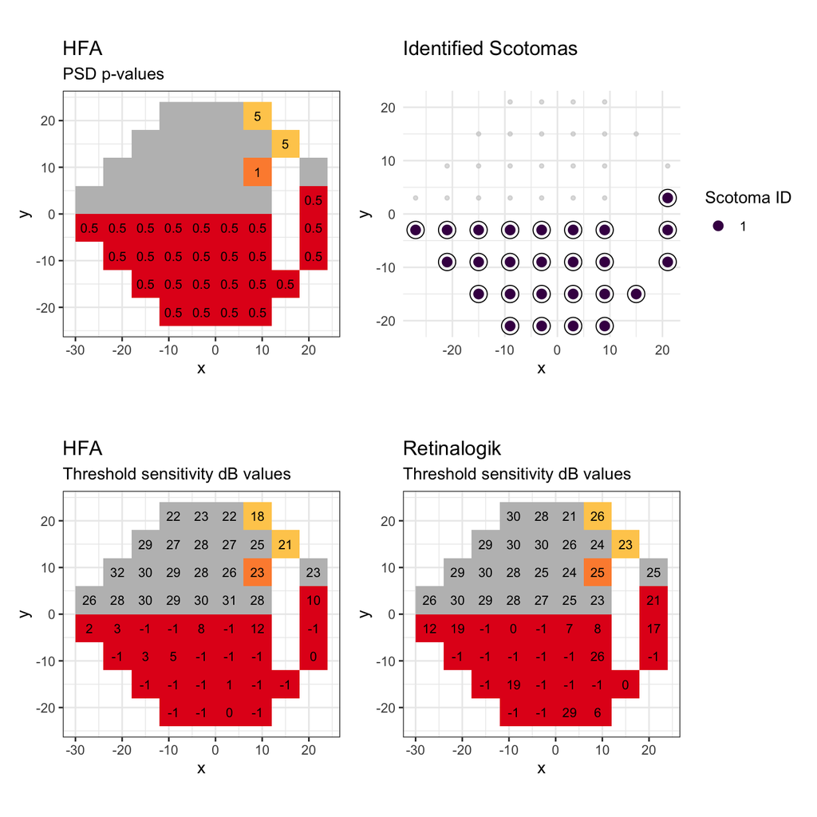

```r
my_data <- psdpvalues_hfa %>%
  filter(datetime==ymd_hms("2025-05-27 10:07:48") & eye=="R")

rttmp <- dBdat %>%
  filter(id=="RL35", visit==4, eye=="R", device=="retinalogik") %>%
  select(id, eye, x, y, dB)

# 1. Data Preparation and Binary Grid Creation
my_data_processed <- my_data %>%
  mutate(psd_p_clean = ifelse(is.na(psd_p), 100, psd_p))

# Convert the data frame to an sf (simple features) object
points_sf <- st_as_sf(my_data_processed, coords = c("x", "y"), crs = NA)

# 2. Filtering Defective Points
# Filter for points where psd_p is less than 5% (including 0.5% and 5.0%)
filtered_points_sf <- points_sf %>%
  filter(psd_p_clean < 5)

# Ensure there are defective points to analyze
if (nrow(filtered_points_sf) > 0) {
  # 3. Connected Components Labeling using Distance-Based Neighbors
  # Create a spatial weights matrix based on distance for the filtered points
  # d1 = 0: minimum distance (points must be distinct)
  # d2 = 9: maximum distance (captures vertical, horizontal, and diagonal neighbors
  #         given your coordinate spacing of 6 units, sqrt(6^2 + 6^2) approx 8.485)
  filtered_neighbors <- dnearneigh(filtered_points_sf, d1 = 0, d2 = 9)

  # Check if there are any connections among the filtered points
  if (length(unlist(filtered_neighbors)) > 0) {
    # Find connected components (contiguous groups)
    components <- n.comp.nb(filtered_neighbors)

    # Assign component IDs back to the filtered data
    filtered_points_sf$component_id <- components$comp.id

    # 4. Filtering Connected Components by Scotoma Criteria
    scotomas_found <- list()
    unique_component_ids <- unique(filtered_points_sf$component_id)

    for (comp_id in unique_component_ids) {
      current_cluster <- filtered_points_sf %>%
        filter(component_id == comp_id)

      num_points <- nrow(current_cluster)
      # Check if any point in this cluster has psd_p < 1% (i.e., psd_p_clean == 0.5)
      has_p_lt_1_percent <- any(current_cluster$psd_p_clean < 1)

      # Apply scotoma definition: at least 3 points AND at least 1 location at p < 1%
      # Apply scotoma definition: at least 3 points AND at least 1 location at p < 1%
      if (num_points >= 3 && has_p_lt_1_percent) {
        scotomas_found[[as.character(comp_id)]] <- current_cluster %>%
          # Extract x and y coordinates from the geometry column
          mutate(
            x_coord = st_coordinates(.)[, "X"],
            y_coord = st_coordinates(.)[, "Y"]
          ) %>%
          # Now select the desired columns, including the newly extracted x_coord and y_coord
          select(x_coord, y_coord, psd_p) %>%
          # Drop the geometry column as it's no longer needed for the table output
          st_drop_geometry() %>%
          # Rename x_coord and y_coord back to x and y for consistency with the table format
          rename(x = x_coord, y = y_coord)
      }
    }

    # Prepare results for the report table
    scotoma_results_list <- list()
    if (length(scotomas_found) > 0) {
      scotoma_id_counter <- 1
      for (scotoma_label in names(scotomas_found)) {
        scotoma_data <- scotomas_found[[scotoma_label]]
        num_points <- nrow(scotoma_data)
        min_psd_p_actual <- min(scotoma_data$psd_p, na.rm = TRUE) # Use original psd_p for reporting

        # Format constituent points string
        constituent_points_str <- paste(
          paste0("(", scotoma_data$x, ",", scotoma_data$y, ") [p=", scotoma_data$psd_p, "%]"),
          collapse = "; "
        )

        scotoma_results_list[[scotoma_id_counter]] <- data.frame(
          Scotoma_ID = scotoma_id_counter,
          Number_of_Points = num_points,
          Minimum_psd_p_percent = min_psd_p_actual,
          Constituent_Points = constituent_points_str,
          stringsAsFactors = FALSE
        )
        scotoma_id_counter <- scotoma_id_counter + 1
      }
    }

    # Final table of identified scotomas
    identified_scotomas_table_df <- if (length(scotoma_results_list) > 0) {
      do.call(rbind, scotoma_results_list)
    } else {
      data.frame(
        Scotoma_ID = integer(),
        Number_of_Points = integer(),
        Minimum_psd_p_percent = numeric(),
        Constituent_Points = character(),
        stringsAsFactors = FALSE
      )
    }

  } else {
    identified_scotomas_table_df <- data.frame(
      Scotoma_ID = integer(),
      Number_of_Points = integer(),
      Minimum_psd_p_percent = numeric(),
      Constituent_Points = character(),
      stringsAsFactors = FALSE
    )
  }
} else {
  identified_scotomas_table_df <- data.frame(
    Scotoma_ID = integer(),
    Number_of_Points = integer(),
    Minimum_psd_p_percent = numeric(),
    Constituent_Points = character(),
    stringsAsFactors = FALSE
  )
}

# Print the table (for verification within the R environment)
print(identified_scotomas_table_df)
>   Scotoma_ID Number_of_Points Minimum_psd_p_percent
> 1          1               26                   0.5
>                                                                                                                                                                                                                                                                                                                                                                                                                                                                          Constituent_Points
> 1 (-15,-15) [p=0.5%]; (-15,-3) [p=0.5%]; (-15,-9) [p=0.5%]; (-21,-3) [p=0.5%]; (-21,-9) [p=0.5%]; (-27,-3) [p=0.5%]; (-3,-15) [p=0.5%]; (-3,-21) [p=0.5%]; (-3,-3) [p=0.5%]; (-3,-9) [p=0.5%]; (-9,-15) [p=0.5%]; (-9,-21) [p=0.5%]; (-9,-3) [p=0.5%]; (-9,-9) [p=0.5%]; (15,-15) [p=0.5%]; (21,-3) [p=0.5%]; (21,-9) [p=0.5%]; (21,3) [p=0.5%]; (3,-15) [p=0.5%]; (3,-21) [p=0.5%]; (3,-3) [p=0.5%]; (3,-9) [p=0.5%]; (9,-15) [p=0.5%]; (9,-21) [p=0.5%]; (9,-3) [p=0.5%]; (9,-9) [p=0.5%]

# Define custom colors for psd_p values for the background raster
customcolors <- brewer.pal(4, "YlOrRd")
customcolors <- rev(customcolors)

# Plot 1: HFA Pattern Deviation Probability Plot (similar to user's 'p' plot)
# This plot shows the psd_p values for all test points.
p_plot <- my_data_processed %>%
  ggplot(aes(x, y)) +
  geom_raster(aes(fill = factor(psd_p))) + # Use original psd_p for fill
  geom_text(aes(label = ifelse(is.na(psd_p), "", psd_p)), size = 3) +
  coord_fixed(ratio = 1) +
  scale_fill_manual(values = customcolors, na.value = "gray") +
  theme_bw() +
  ggtitle("HFA", subtitle = "PSD p-values") +
  theme(legend.position = "none")

dB_plot <- my_data_processed %>%
  ggplot(aes(x, y)) +
  geom_raster(aes(fill = factor(psd_p))) + # Use original psd_p for fill
  geom_text(aes(label = ifelse(is.na(dB), "", dB)), size = 3) +
  coord_fixed(ratio = 1) +
  scale_fill_manual(values = customcolors, na.value = "gray") +
  theme_bw() +
  ggtitle("HFA", subtitle = "Threshold sensitivity dB values") +
  theme(legend.position = "none")

rttmp_filtered_for_plot <- rttmp %>%
  semi_join(my_data_processed, by = c("x", "y"))

# Join filtered_rttmp with my_data_processed to get psd_p for coloring the background
rttmp_for_plot_with_psdp <- rttmp_filtered_for_plot %>%
  left_join(my_data_processed %>% select(x, y, psd_p), by = c("x", "y"))

# Plot 4: Retinalogik Threshold Sensitivity dB values
rt_plot <- rttmp_for_plot_with_psdp %>%
  ggplot(aes(x, y)) +
  geom_raster(aes(fill = factor(psd_p))) + # Use HFA psd_p for fill as per user's example
  geom_text(aes(label = ifelse(is.na(dB), "", dB)), size = 3) + # Use Retinalogik dB for label
  coord_fixed(ratio = 1) +
  scale_fill_manual(values = customcolors, na.value = "gray") +
  theme_bw() +
  ggtitle("Retinalogik", subtitle = "Threshold sensitivity dB values") +
  theme(legend.position = "none")

# Prepare data for the scotoma highlight plot
# Combine all identified scotoma points into a single data frame for plotting
all_scotoma_points_for_plot <- data.frame()
if (length(scotomas_found) > 0) {
  scotoma_id_map <- 1
  for (original_comp_id in names(scotomas_found)) {
    temp_df <- scotomas_found[[original_comp_id]]
    temp_df$scotoma_plot_id <- scotoma_id_map # Assign a sequential ID for plotting colors
    all_scotoma_points_for_plot <- bind_rows(all_scotoma_points_for_plot, temp_df)
    scotoma_id_map <- scotoma_id_map + 1
  }
}

# Plot 2: Identified Scotomas Highlighted (similar to user's 'plot_scotoma')
# This plot overlays the identified scotoma points on a grey background of all points.
plot_scotoma_highlight <- ggplot() +
  geom_point(data = my_data_processed, aes(x = x, y = y), color = "grey", size = 1, alpha = 0.5) + # All points as background
  {
    if (nrow(all_scotoma_points_for_plot) > 0) {
      list(
        geom_point(data = all_scotoma_points_for_plot,
                   aes(x = x, y = y, color = as.factor(scotoma_plot_id)),
                   size = 3, shape = 16), # Highlight scotoma points
        scale_color_viridis_d(option = "viridis", name = "Scotoma ID"), # Use viridis for distinct scotoma colors
        geom_point(data = all_scotoma_points_for_plot,
                   aes(x = x, y = y),
                   color = "black", size = 5, shape = 1) # Add black outline for emphasis
      )
    }
  } +
  labs(title = "Identified Scotomas",
       x = "x", y = "y") +
  theme_minimal() +
  theme(legend.position = "right")

(p_plot + plot_scotoma_highlight)/
  (dB_plot + rt_plot)
```

#### Visit 5

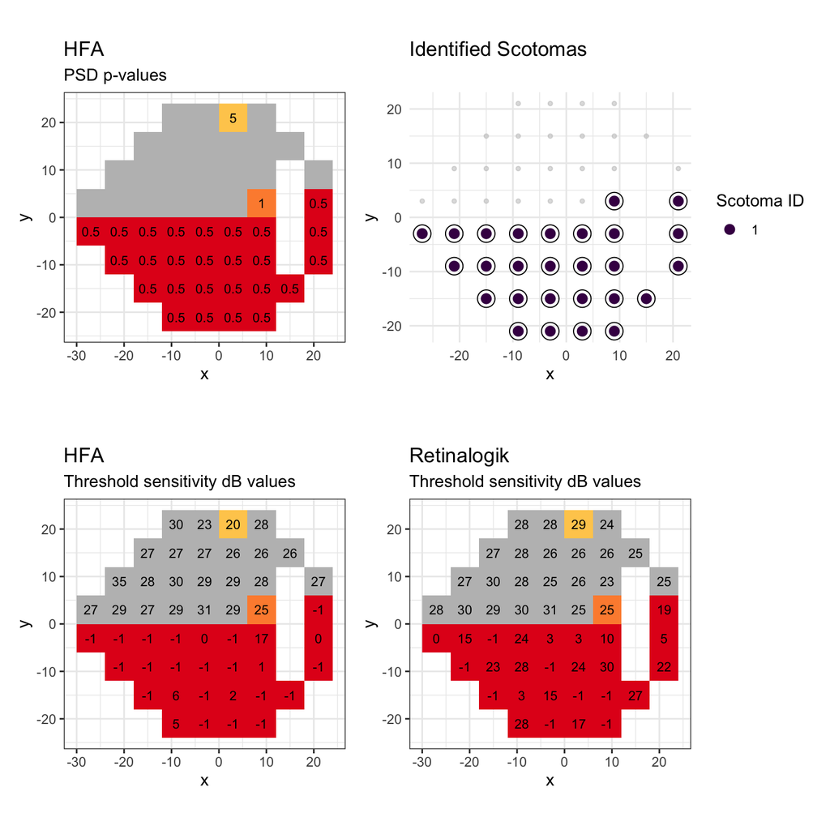

```r
my_data <- psdpvalues_hfa %>%
  filter(datetime==ymd_hms("2025-05-29 09:47:54") & eye=="R")

rttmp <- dBdat %>%
  filter(id=="RL35", visit==5, eye=="R", device=="retinalogik") %>%
  select(id, eye, x, y, dB)

# 1. Data Preparation and Binary Grid Creation
my_data_processed <- my_data %>%
  mutate(psd_p_clean = ifelse(is.na(psd_p), 100, psd_p))

# Convert the data frame to an sf (simple features) object
points_sf <- st_as_sf(my_data_processed, coords = c("x", "y"), crs = NA)

# 2. Filtering Defective Points
# Filter for points where psd_p is less than 5% (including 0.5% and 5.0%)
filtered_points_sf <- points_sf %>%
  filter(psd_p_clean < 5)

# Ensure there are defective points to analyze
if (nrow(filtered_points_sf) > 0) {
  # 3. Connected Components Labeling using Distance-Based Neighbors
  # Create a spatial weights matrix based on distance for the filtered points
  # d1 = 0: minimum distance (points must be distinct)
  # d2 = 9: maximum distance (captures vertical, horizontal, and diagonal neighbors
  #         given your coordinate spacing of 6 units, sqrt(6^2 + 6^2) approx 8.485)
  filtered_neighbors <- dnearneigh(filtered_points_sf, d1 = 0, d2 = 9)

  # Check if there are any connections among the filtered points
  if (length(unlist(filtered_neighbors)) > 0) {
    # Find connected components (contiguous groups)
    components <- n.comp.nb(filtered_neighbors)

    # Assign component IDs back to the filtered data
    filtered_points_sf$component_id <- components$comp.id

    # 4. Filtering Connected Components by Scotoma Criteria
    scotomas_found <- list()
    unique_component_ids <- unique(filtered_points_sf$component_id)

    for (comp_id in unique_component_ids) {
      current_cluster <- filtered_points_sf %>%
        filter(component_id == comp_id)

      num_points <- nrow(current_cluster)
      # Check if any point in this cluster has psd_p < 1% (i.e., psd_p_clean == 0.5)
      has_p_lt_1_percent <- any(current_cluster$psd_p_clean < 1)

      # Apply scotoma definition: at least 3 points AND at least 1 location at p < 1%
      # Apply scotoma definition: at least 3 points AND at least 1 location at p < 1%
      if (num_points >= 3 && has_p_lt_1_percent) {
        scotomas_found[[as.character(comp_id)]] <- current_cluster %>%
          # Extract x and y coordinates from the geometry column
          mutate(
            x_coord = st_coordinates(.)[, "X"],
            y_coord = st_coordinates(.)[, "Y"]
          ) %>%
          # Now select the desired columns, including the newly extracted x_coord and y_coord
          select(x_coord, y_coord, psd_p) %>%
          # Drop the geometry column as it's no longer needed for the table output
          st_drop_geometry() %>%
          # Rename x_coord and y_coord back to x and y for consistency with the table format
          rename(x = x_coord, y = y_coord)
      }
    }

    # Prepare results for the report table
    scotoma_results_list <- list()
    if (length(scotomas_found) > 0) {
      scotoma_id_counter <- 1
      for (scotoma_label in names(scotomas_found)) {
        scotoma_data <- scotomas_found[[scotoma_label]]
        num_points <- nrow(scotoma_data)
        min_psd_p_actual <- min(scotoma_data$psd_p, na.rm = TRUE) # Use original psd_p for reporting

        # Format constituent points string
        constituent_points_str <- paste(
          paste0("(", scotoma_data$x, ",", scotoma_data$y, ") [p=", scotoma_data$psd_p, "%]"),
          collapse = "; "
        )

        scotoma_results_list[[scotoma_id_counter]] <- data.frame(
          Scotoma_ID = scotoma_id_counter,
          Number_of_Points = num_points,
          Minimum_psd_p_percent = min_psd_p_actual,
          Constituent_Points = constituent_points_str,
          stringsAsFactors = FALSE
        )
        scotoma_id_counter <- scotoma_id_counter + 1
      }
    }

    # Final table of identified scotomas
    identified_scotomas_table_df <- if (length(scotoma_results_list) > 0) {
      do.call(rbind, scotoma_results_list)
    } else {
      data.frame(
        Scotoma_ID = integer(),
        Number_of_Points = integer(),
        Minimum_psd_p_percent = numeric(),
        Constituent_Points = character(),
        stringsAsFactors = FALSE
      )
    }

  } else {
    identified_scotomas_table_df <- data.frame(
      Scotoma_ID = integer(),
      Number_of_Points = integer(),
      Minimum_psd_p_percent = numeric(),
      Constituent_Points = character(),
      stringsAsFactors = FALSE
    )
  }
} else {
  identified_scotomas_table_df <- data.frame(
    Scotoma_ID = integer(),
    Number_of_Points = integer(),
    Minimum_psd_p_percent = numeric(),
    Constituent_Points = character(),
    stringsAsFactors = FALSE
  )
}

# Print the table (for verification within the R environment)
print(identified_scotomas_table_df)
>   Scotoma_ID Number_of_Points Minimum_psd_p_percent
> 1          1               27                   0.5
>                                                                                                                                                                                                                                                                                                                                                                                                                                                                                        Constituent_Points
> 1 (-15,-15) [p=0.5%]; (-15,-3) [p=0.5%]; (-15,-9) [p=0.5%]; (-21,-3) [p=0.5%]; (-21,-9) [p=0.5%]; (-27,-3) [p=0.5%]; (-3,-15) [p=0.5%]; (-3,-21) [p=0.5%]; (-3,-3) [p=0.5%]; (-3,-9) [p=0.5%]; (-9,-15) [p=0.5%]; (-9,-21) [p=0.5%]; (-9,-3) [p=0.5%]; (-9,-9) [p=0.5%]; (15,-15) [p=0.5%]; (21,-3) [p=0.5%]; (21,-9) [p=0.5%]; (21,3) [p=0.5%]; (3,-15) [p=0.5%]; (3,-21) [p=0.5%]; (3,-3) [p=0.5%]; (3,-9) [p=0.5%]; (9,-15) [p=0.5%]; (9,-21) [p=0.5%]; (9,-3) [p=0.5%]; (9,-9) [p=0.5%]; (9,3) [p=1%]

# Define custom colors for psd_p values for the background raster
customcolors <- brewer.pal(4, "YlOrRd")
customcolors <- rev(customcolors)

# Plot 1: HFA Pattern Deviation Probability Plot (similar to user's 'p' plot)
# This plot shows the psd_p values for all test points.
p_plot <- my_data_processed %>%
  ggplot(aes(x, y)) +
  geom_raster(aes(fill = factor(psd_p))) + # Use original psd_p for fill
  geom_text(aes(label = ifelse(is.na(psd_p), "", psd_p)), size = 3) +
  coord_fixed(ratio = 1) +
  scale_fill_manual(values = customcolors, na.value = "gray") +
  theme_bw() +
  ggtitle("HFA", subtitle = "PSD p-values") +
  theme(legend.position = "none")

dB_plot <- my_data_processed %>%
  ggplot(aes(x, y)) +
  geom_raster(aes(fill = factor(psd_p))) + # Use original psd_p for fill
  geom_text(aes(label = ifelse(is.na(dB), "", dB)), size = 3) +
  coord_fixed(ratio = 1) +
  scale_fill_manual(values = customcolors, na.value = "gray") +
  theme_bw() +
  ggtitle("HFA", subtitle = "Threshold sensitivity dB values") +
  theme(legend.position = "none")

rttmp_filtered_for_plot <- rttmp %>%
  semi_join(my_data_processed, by = c("x", "y"))

# Join filtered_rttmp with my_data_processed to get psd_p for coloring the background
rttmp_for_plot_with_psdp <- rttmp_filtered_for_plot %>%
  left_join(my_data_processed %>% select(x, y, psd_p), by = c("x", "y"))

# Plot 4: Retinalogik Threshold Sensitivity dB values
rt_plot <- rttmp_for_plot_with_psdp %>%
  ggplot(aes(x, y)) +
  geom_raster(aes(fill = factor(psd_p))) + # Use HFA psd_p for fill as per user's example
  geom_text(aes(label = ifelse(is.na(dB), "", dB)), size = 3) + # Use Retinalogik dB for label
  coord_fixed(ratio = 1) +
  scale_fill_manual(values = customcolors, na.value = "gray") +
  theme_bw() +
  ggtitle("Retinalogik", subtitle = "Threshold sensitivity dB values") +
  theme(legend.position = "none")

# Prepare data for the scotoma highlight plot
# Combine all identified scotoma points into a single data frame for plotting
all_scotoma_points_for_plot <- data.frame()
if (length(scotomas_found) > 0) {
  scotoma_id_map <- 1
  for (original_comp_id in names(scotomas_found)) {
    temp_df <- scotomas_found[[original_comp_id]]
    temp_df$scotoma_plot_id <- scotoma_id_map # Assign a sequential ID for plotting colors
    all_scotoma_points_for_plot <- bind_rows(all_scotoma_points_for_plot, temp_df)
    scotoma_id_map <- scotoma_id_map + 1
  }
}

# Plot 2: Identified Scotomas Highlighted (similar to user's 'plot_scotoma')
# This plot overlays the identified scotoma points on a grey background of all points.
plot_scotoma_highlight <- ggplot() +
  geom_point(data = my_data_processed, aes(x = x, y = y), color = "grey", size = 1, alpha = 0.5) + # All points as background
  {
    if (nrow(all_scotoma_points_for_plot) > 0) {
      list(
        geom_point(data = all_scotoma_points_for_plot,
                   aes(x = x, y = y, color = as.factor(scotoma_plot_id)),
                   size = 3, shape = 16), # Highlight scotoma points
        scale_color_viridis_d(option = "viridis", name = "Scotoma ID"), # Use viridis for distinct scotoma colors
        geom_point(data = all_scotoma_points_for_plot,
                   aes(x = x, y = y),
                   color = "black", size = 5, shape = 1) # Add black outline for emphasis
      )
    }
  } +
  labs(title = "Identified Scotomas",
       x = "x", y = "y") +
  theme_minimal() +
  theme(legend.position = "right")

(p_plot + plot_scotoma_highlight)/
  (dB_plot + rt_plot)
```

Report by [Vivian Eng](https://ca.linkedin.com/in/vivianjleng)

*vivian@eadietech.com*